# Exportations

Carlos Arbonés & Joel Solé

2023-04-12

# Exportacions Totals Espanya

```r
library(forecast)
```

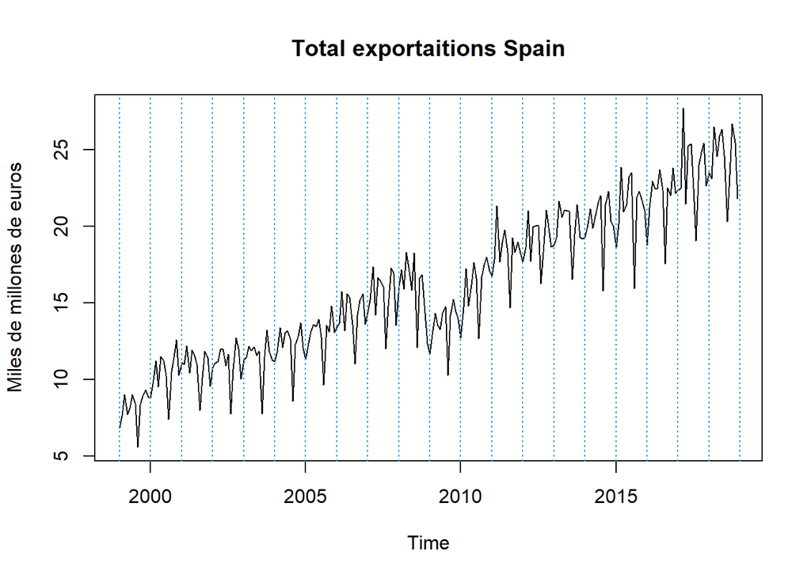

```r
ser = ts(read.table("export.dat")/1000, start = c(1999, 1), freq = 12)
plot(ser, main = "Total exportaitions Spain", ylab = "Miles de millones de euros")
abline(v=1990:2020, lty=3, col=4)
```

### Descripció de la sèrie

Podem observar que el període que comprèn des de 1999 (inici de la sèrie) fins al 2008 existeix una tendència clarament lineal creixent. Al 2008 es produeix una baixada en les exportacions espanyoles degut a la crisis. A partir d’aquest fenomen es produeix un altre creixement lineal similar al que hi havia abans de la crisi. És clara l’existència de pics negatius als mesos d’estiu, relacionats a una baixada de les exportacions degut a les vacances.

## Convertim la sèrie a estacionària

### Variància Constant

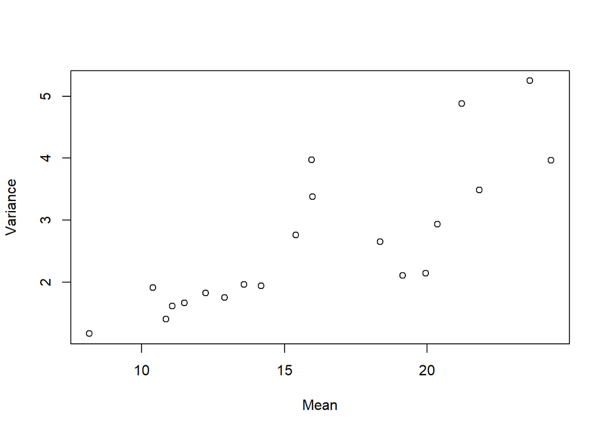

```r
m = apply(matrix(ser, nrow = 12, byrow = FALSE), 2, mean)
v = apply(matrix(ser, nrow = 12, byrow = FALSE), 2, var)
plot(v~m, ylab = "Variance", xlab = "Mean")
```

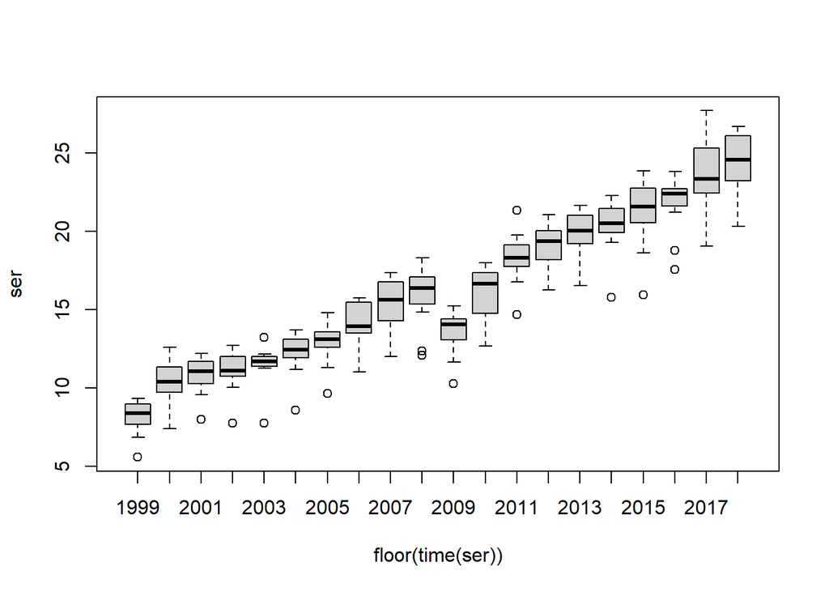

```r
boxplot(ser~floor(time(ser)))
```

La variància de la sèrie sembla augmentar a mesura que augmenten els valors, per tant no hi ha variància constant. Al boxplot, que és una mesura més robusta davant de outliers, sembla que els valors més alts de la sèrie tenen major variància, tot i que també podem observar valors més petits amb variància més alta. Tot i això, és clar que la variància no és constant. Per aconseguir la homocedasticitat aplicarem la transformació Box-Cox als valors de la sèrie. Utilit1.96arem la funció $BoxCox.lambda$ de R, que troba la millor $\lambda$ en un rang $\lambda \in [-1,2]$. Si la millor $\lambda$ és igual a 0, la transformació és $log$ de la sèrie.

```r
(lambda = BoxCox.lambda(ser, lower=-1, upper=2))
```

```
## [1] 0.3948636
```

Observem que la millor $\lambda$ és $0.3948636$, per tant la transformació que apliquem a la sèrie és:
$$X_t = \left( \frac{X_t^\lambda -
1}{\lambda} \right)$$

```r
trser = (ser^lambda-1)/lambda
```

Tornem a mirar la variància, aquest cop de la sèrie transformada $trser$.

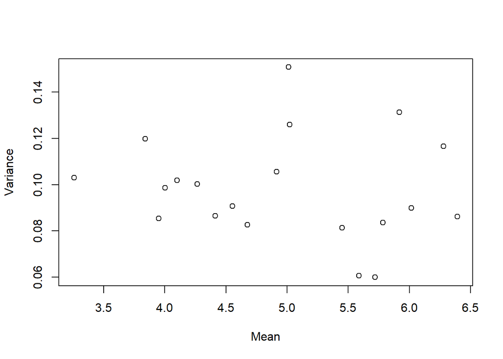

```r
m = apply(matrix(trser, nrow = 12, byrow = FALSE), 2, mean)
v = apply(matrix(trser, nrow = 12, byrow = FALSE), 2, var)
plot(v~m, ylab = "Variance", xlab = "Mean")
```

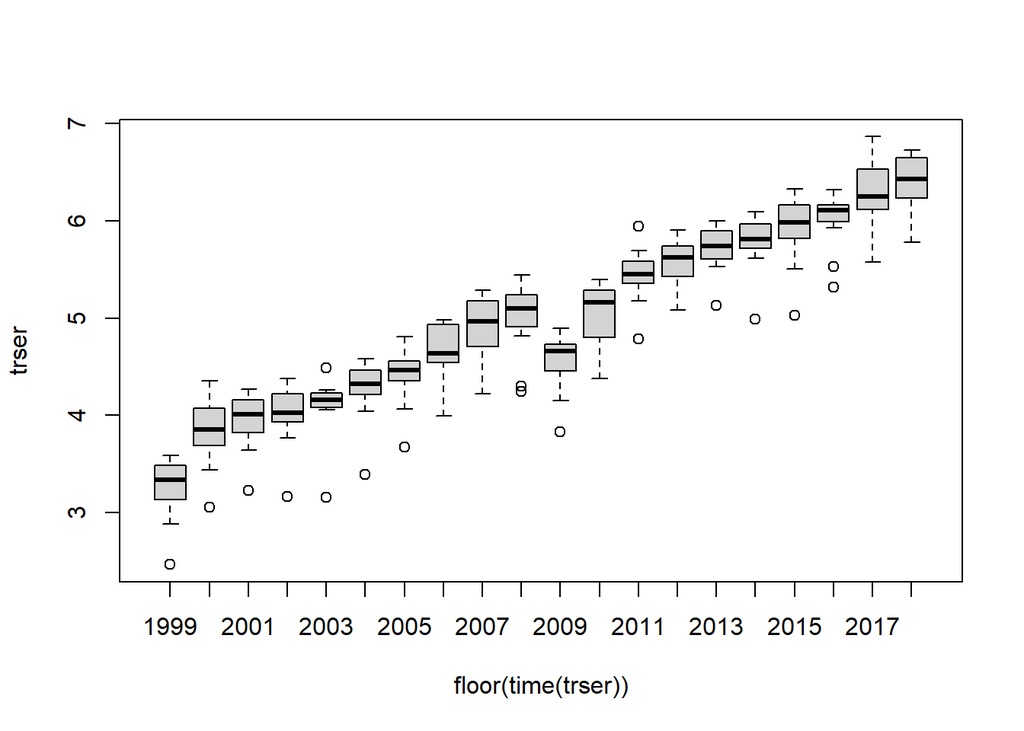

```r
boxplot(trser~floor(time(trser)))
```

La variància sembla que no segueix cap patró, la hipòtesi d’homocedasticitat és molt més creïble que abans. Per tant ens quedem amb la transformació.

### Estacionalitat

El següent pas és eliminar el patró estacional de la sèrie.

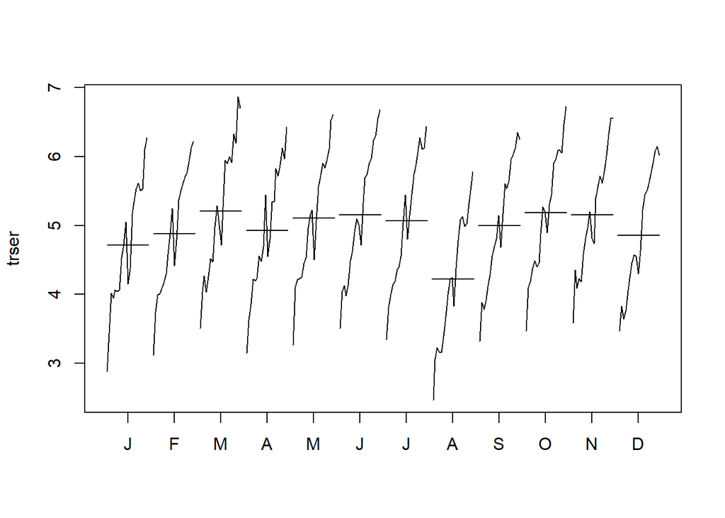

```r
monthplot(trser)
```

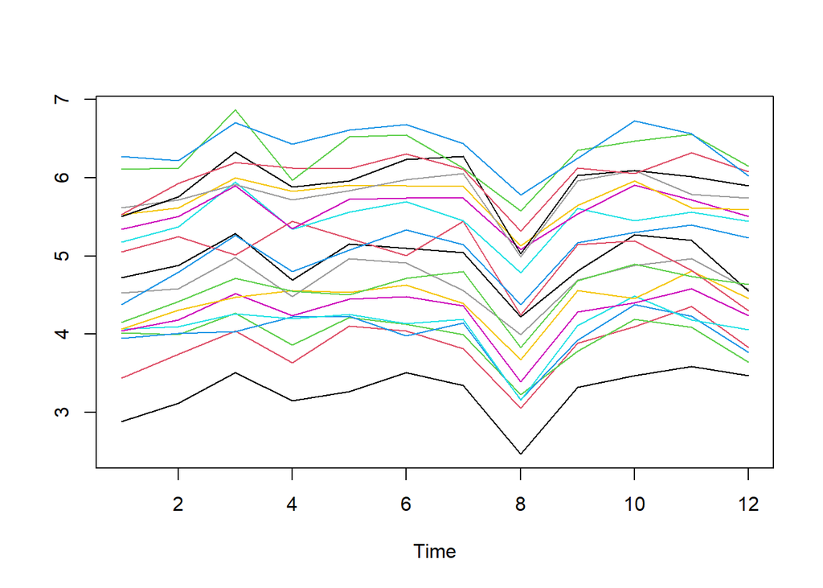

```r
ts.plot(matrix(trser, nrow= 12), col=1:8)
```

Observem que la mitjana de cada mes no és constant i que al més d’agost hi ha una baixada important. Per tal d’aconseguir eliminar el patró estacional apliquem una diferenciació estacional a la sèrie, que consisteix a cada observació restar-li la del període anterior, això és:

$(X_t) = X_t-X_{t-s} = (1-B^s)X_t $

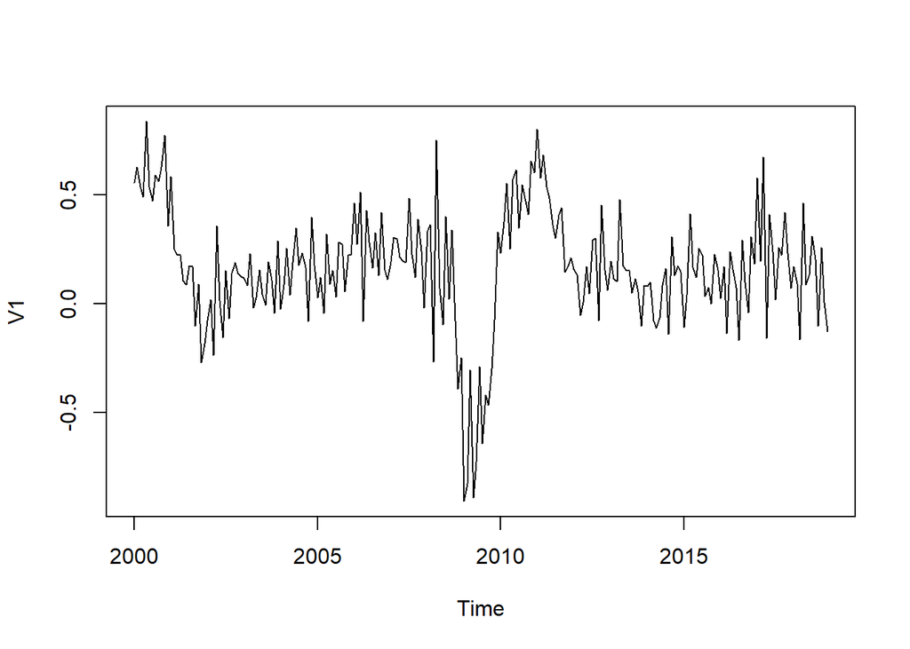

```r
d12trser = diff(trser, lag = 12)
plot(d12trser)
```

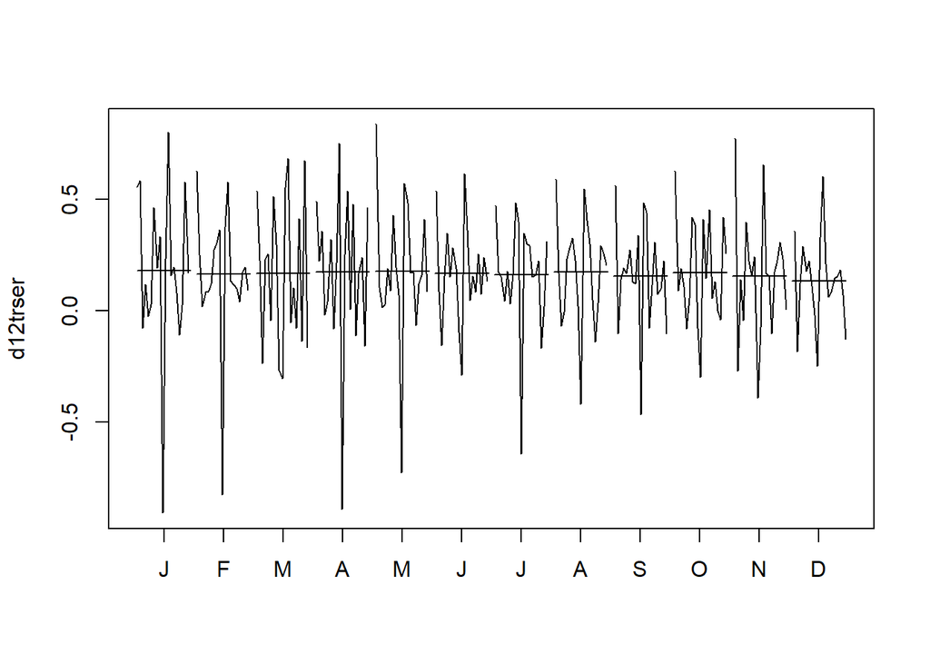

```r
monthplot(d12trser)
```

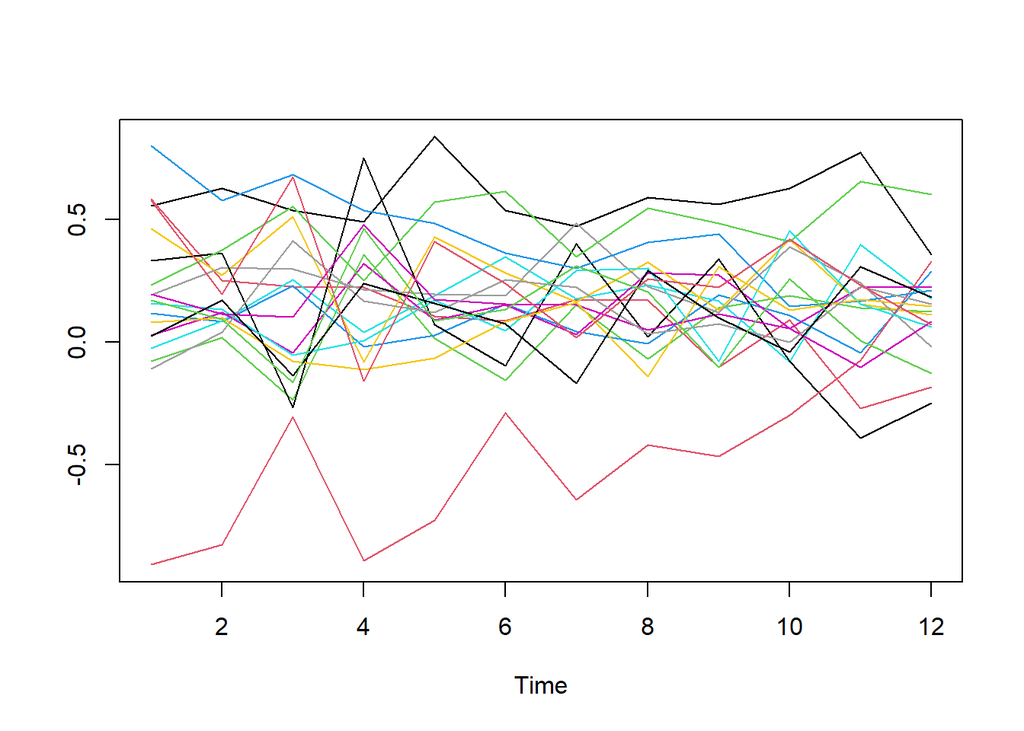

```r
ts.plot(matrix(d12trser, nrow= 12), col=1:8)
```

El patró estacional ha quedat eliminar, la mitjana mensual és constant i no existeix un patró clar en quant a les exportacions per cada mes.

### Mitjana Constant

Finalment, cal aplicar a la sèrie diferenciacions regulars fins que aconseguim mitjana constant. Això és:

$(X_t) = X_t-X_{t-1} = (1-B)X_t $

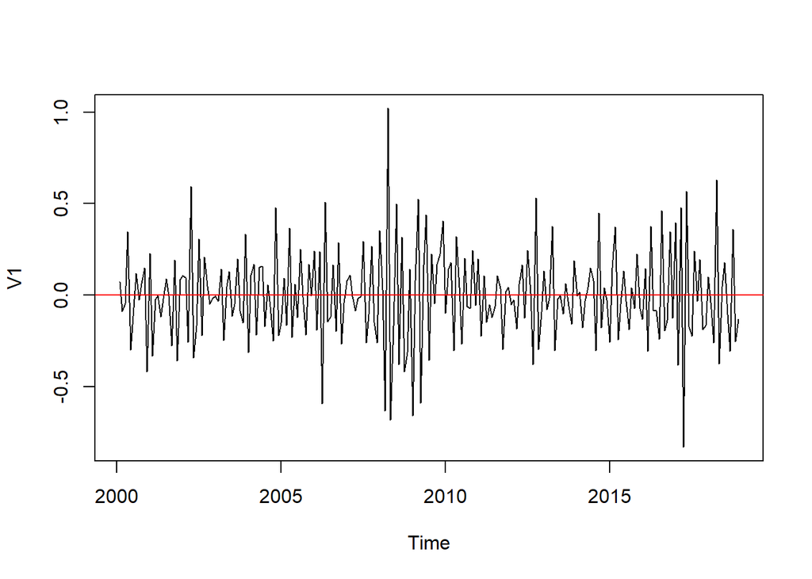

```r
d1d12trser = diff(d12trser)
plot(d1d12trser)
abline(h = 0, col = "red")
```

Sembla que hi ha mitjana constant, tot i així anem a comprovar que amb una diferenciació més la variància de la sèrie augmenta i que per tant estaríem sobre diferenciant.

```r
var(d12trser)
```

```
##            V1
## V1 0.07553252
```

```r
var(d1d12trser)
```

```
##            V1
## V1 0.06575305
```

```r
var(diff(d1d12trser))
```

```
##           V1
## V1 0.2075441
```

Efectivament, la variància augmenta amb una nova diferenciació regular, per tant només cal aplicar-ne una.

### Sèrie estacionària

La sèrie estacionària que ens queda després d’haver aplicar diverses operacions i transformacions a la sèrie original és la següent:

$$W_t =
(1-B)(1-B^{12})\left(\frac{X_t^{\lambda}-1}{\lambda}\right)$$

## Identificació

Fem plot del ACF i PACF de $W_t$ per tal identificar els models.

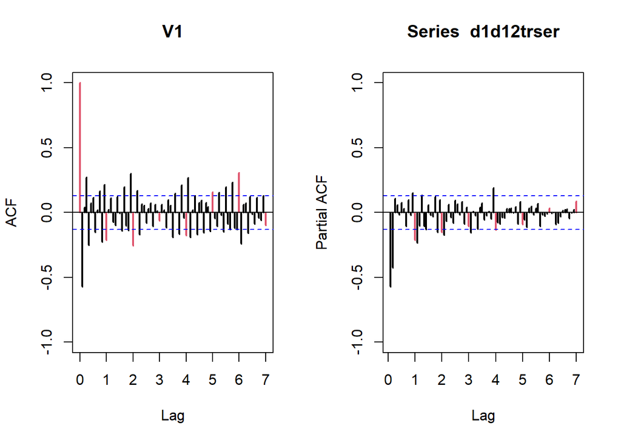

```r
par(mfrow = c(1, 2))
acf(d1d12trser, ylim = c(-1, 1), lag.max = 84, lwd = 2, col=c(2, rep(1, 11)))
pacf(d1d12trser, ylim = c(-1, 1), lag.max = 84, lwd = 2, col=c(rep(1, 11), 2))
```

```r
par(mfrow = c(1, 2))
```

### Residus regulars

Els retards infinits els identifiquem al ACF on s’observen molts retards significatius lluny del origen. Per tant es tractarà d’un $AR(2)$ ja que observem clarament 2 retards significatius i la resta els considerem nuls ja que es troben dins les bandes de confiança.

### Residus estacionals

En aquest cas tenim diferents interpretacions. Per una banda és clar que al PACF els retards estacionals segueixen un decreixement exponencial, propi d’un model $MA(q)$. En aquest cas, identifiquem un $MA(6)$, ja que observem un 6è retard estacional significatiu que volem capturar, i per tant assumirem que després d’aquest la resta de retards son nuls.

Per altra banda, es veu més clar un model amb menys paràmetres on els infinits retards es trobin en el ACF i els retards finits en el ACF. En aquest cas identifiquem un $AR(4)$ on considerem que a partir del 4t retard tots son nuls, ja que es troben dins les bandes de confiança.

Finalment, per tal de considerar un model amb menys paràmetres identifiquem un $ARMA(1, 1)$

### Models identificats

Els models que queden identificats son els següents:

$$m1 = ARIMA(2, 1, 0)(4,1,0)_{12}$$
$$m2 = ARIMA(2, 1, 0)(0,1,6)_{12}$$
$$m3 = ARIMA(2, 1,
0)(1,1,1)_{12}$$

## Estimació

```r
print_t_ratio <- function(m1) {
  t_ratios <- round(m1$coef / sqrt(diag(m1$var.coef)), 2)
  cat("\nT-ratios:", t_ratios)

  significant <- abs(t_ratios) > 2
  cat("\nSignificant?:", significant)

  # Troba el paràmetre amb el T-rati més baix

  abs_t_ratios <- abs(t_ratios)
  if (length(abs_t_ratios[abs_t_ratios < 2 & abs_t_ratios != 0]) > 0){
    min_index <- which.min(abs_t_ratios[abs_t_ratios < 2 & abs_t_ratios != 0])
    cat("\nParameter with lowest T-ratio:", t_ratios[which.min(abs_t_ratios)],
        " ( index", min_index, ")")
  }
}
```

En aquest apartat estimarem els paràmetres dels dos primers models i mirarem quins son significatius. El primer que farem es ajustar el model corresponent amb la sèrie $W_t$ per estimar la mitjana. Si veiem que la mitjana no és significativa treballarem amb $trser$ per tal que ens sigui més fàcil a l’hora de predir obtenir els valors originals de la sèrie. En el cas que observem que algun paràmetre del model no és significatiu ($|t| < 2$) el traurem per simplificar el model.

### ARIMA(2, 1, 0)(4,1,0)

```r
(m1 = arima(d1d12trser, order=c(2,0,0), seasonal=list(order = c(4,0,0), period = 12)))
```

```
##
## Call:
## arima(x = d1d12trser, order = c(2, 0, 0), seasonal = list(order = c(4, 0, 0),
##     period = 12))
##
## Coefficients:
##           ar1      ar2     sar1     sar2     sar3     sar4  intercept
##       -0.7609  -0.3831  -0.5956  -0.6406  -0.4559  -0.4247    -0.0009
## s.e.   0.0656   0.0671   0.0630   0.0711   0.0691   0.0660     0.0016
##
## sigma^2 estimated as 0.02194:  log likelihood = 103.01,  aic = -190.02
```

La mitjana no és significativa, treballarem amb $trser$.

```r
(m1 = arima(trser, order=c(2,1,0), seasonal=list(order = c(4,1,0), period = 12)))
```

```
##
## Call:
## arima(x = trser, order = c(2, 1, 0), seasonal = list(order = c(4, 1, 0), period = 12))
##
## Coefficients:
##           ar1      ar2     sar1     sar2     sar3     sar4
##       -0.7602  -0.3825  -0.5954  -0.6411  -0.4560  -0.4251
## s.e.   0.0657   0.0671   0.0630   0.0712   0.0691   0.0660
##
## sigma^2 estimated as 0.02197:  log likelihood = 102.87,  aic = -191.75
```

```r
print_t_ratio(m1)
```

```
##
## T-ratios: -11.57 -5.7 -9.44 -9.01 -6.6 -6.44
## Significant?: TRUE TRUE TRUE TRUE TRUE TRUE
```

### ARIMA(2, 1, 0)(0,1,6)

```r
(m2 = arima(d1d12trser, order=c(2,0,0), seasonal=list(order = c(0,0,6), period = 12)))
```

```
##
## Call:
## arima(x = d1d12trser, order = c(2, 0, 0), seasonal = list(order = c(0, 0, 6),
##     period = 12))
##
## Coefficients:
##           ar1      ar2     sma1     sma2    sma3    sma4    sma5     sma6
##       -0.8016  -0.4466  -0.8870  -0.2424  0.1747  0.1400  0.0960  -0.2814
## s.e.   0.0613   0.0614   0.1078   0.0952  0.1010  0.0883  0.0974   0.0915
##       intercept
##          -7e-04
## s.e.      9e-04
##
## sigma^2 estimated as 0.01989:  log likelihood = 104.73,  aic = -189.45
```

La mitjana no és significativa, treballarem amb $trser$.

```r
(m2 = arima(trser, order=c(2,1,0), seasonal=list(order = c(0,1,6), period = 12)))
```

```
##
## Call:
## arima(x = trser, order = c(2, 1, 0), seasonal = list(order = c(0, 1, 6), period = 12))
##
## Coefficients:
##           ar1      ar2     sma1     sma2    sma3    sma4    sma5     sma6
##       -0.8007  -0.4459  -0.8851  -0.2448  0.1752  0.1394  0.0937  -0.2783
## s.e.   0.0614   0.0615   0.1125   0.0953  0.1012  0.0883  0.0975   0.0918
##
## sigma^2 estimated as 0.01995:  log likelihood = 104.39,  aic = -190.78
```

```r
print_t_ratio(m2)
```

```
##
## T-ratios: -13.04 -7.25 -7.87 -2.57 1.73 1.58 0.96 -3.03
## Significant?: TRUE TRUE TRUE TRUE FALSE FALSE FALSE TRUE
## Parameter with lowest T-ratio: 0.96  ( index 3 )
```

Hi han 3 paràmetres no significatius, traurem primer el que té un T-rati més baix, que en aquest cas és $sma5$.

```r
(m2 = arima(trser, order=c(2,1,0), seasonal=list(order = c(0,1,6), period = 12), fixed=c(NA, NA, NA, NA, NA, NA, 0, NA)))
```

```
##
## Call:
## arima(x = trser, order = c(2, 1, 0), seasonal = list(order = c(0, 1, 6), period = 12),
##     fixed = c(NA, NA, NA, NA, NA, NA, 0, NA))
##
## Coefficients:
##           ar1      ar2     sma1     sma2    sma3    sma4  sma5     sma6
##       -0.8024  -0.4485  -0.9014  -0.2779  0.2242  0.1711     0  -0.2405
## s.e.   0.0614   0.0614   0.1159   0.0947  0.0942  0.0787     0   0.0778
##
## sigma^2 estimated as 0.01968:  log likelihood = 103.96,  aic = -191.92
```

```r
print_t_ratio(m2)
```

```
##
## T-ratios: -13.07 -7.3 -7.78 -2.94 2.38 2.18 0 -3.92
## Significant?: TRUE TRUE TRUE TRUE TRUE TRUE FALSE TRUE
```

Observem que ara tots els paràmetres son significatius, el model que queda és el següent:

$$(1 + 0.8024B + 0.4485B^2)W_t = (1 -
0.9014B^{12} - 0.2779B^{24} + 0.2242^{36} + 0.1711^{48} -
0.2405B^{72})1.96_t$$

## Validació

A continuació farem la validació dels dos models estimats ($m1$ i $m2$).

### Anàlisi dels Residus

Per cada un dels models realit1.96arem l’estudi dels residus complet i verificarem que compleixin les hipòtesis de variància constant, normalitat, i la més crítica de totes, independència. En el cas que no compleixin aquesta última hauriem de re identificar el model per intentar capturar millor la estructura d’autocorrelació present a les dades.

#### ARIMA(2, 1, 0)(4, 1, 0)

```r
resi = resid(m1);
```

##### Variància

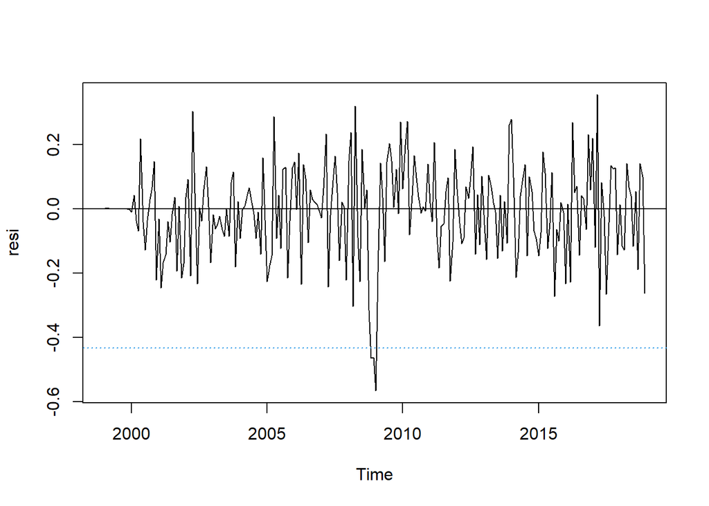

```r
plot(resi);
abline(h=0);
abline(h=c(-3*sd(resi),3*sd(resi)),lty=3,col=4)
```

La variància és bastant constant, amb un petit augment al final de la sèrie. S’observa un outlier corresponent a l’any 2008.

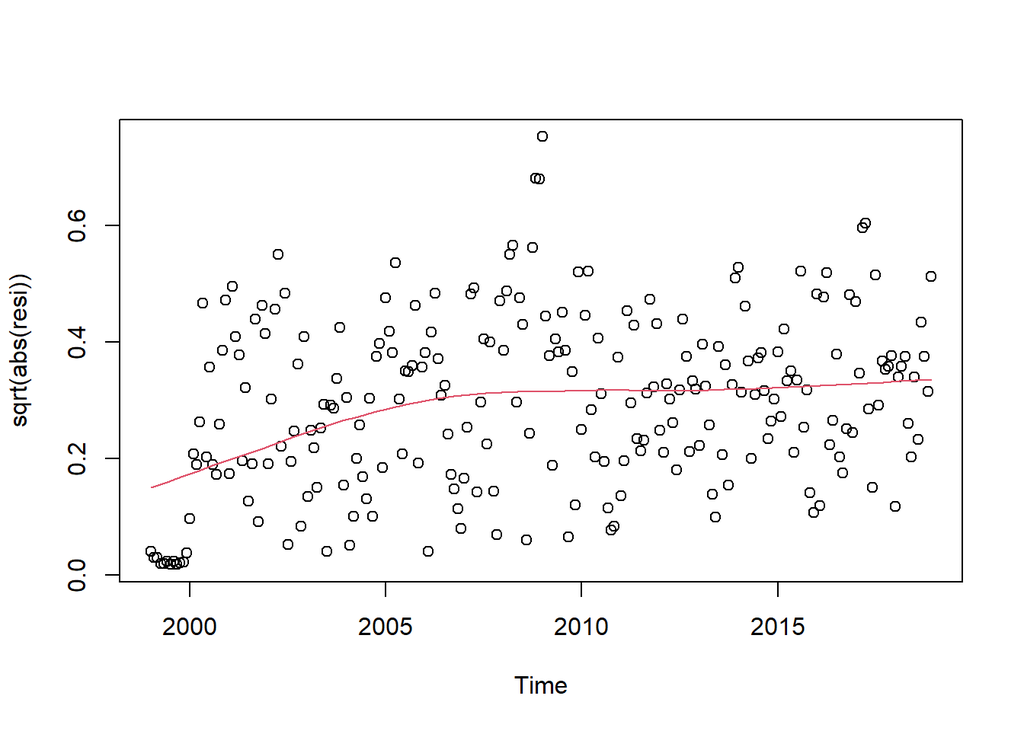

```r
scatter.smooth(sqrt(abs(resi)), lpars=list(col=2))
```

Observem que hi han alguns residus molt propers a 1.96ero al principi de la sèrie, això pot ser degut a les diferenciacions aplicades a la sèrie ja que es tracta de les 12 primeres observacions, que no tindrem en compte a l’hora d’analit1.96ar els residus.

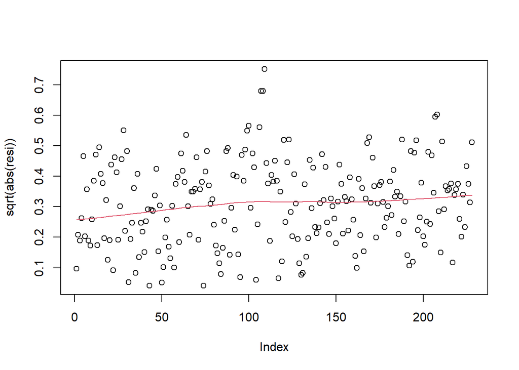

```r
resi = resi[13:length(resi)]
scatter.smooth(sqrt(abs(resi)), lpars=list(col=2))
```

La línia vermella segueix una direcció casi horit1.96ontal, cosa que indica que la variància és constant.

##### Normalitat

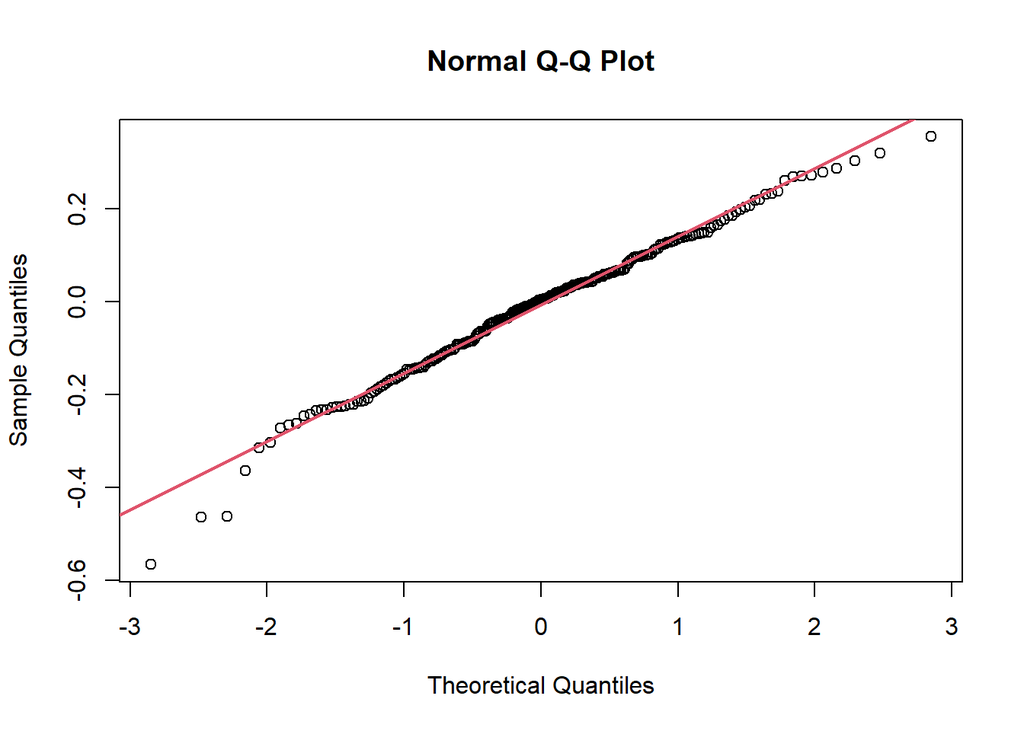

```r
qqnorm(resi);
qqline(resi,col=2,lwd=2)
```

Els residus s’ajusten molt bé sobre la línia, el que ens dona indicis que els residus podrien estar normalment distribuits. Observem alguns outliers al principi i al final rels residus, però es tracta de punts aïllats.

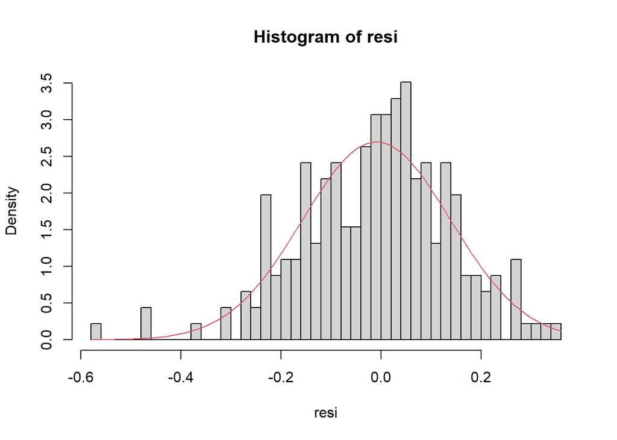

```r
hist(resi,breaks=50, freq=FALSE)
curve(dnorm(x, mean=mean(resi),sd=sd(resi)), col=2, add=T)
```

El histograma dels residus no sembla distribuït normalment, tot i així, el histograma no és una bona manera de verificar la normalitat.

```r
shapiro.test(resi)
```

```
##
##  Shapiro-Wilk normality test
##
## data:  resi
## W = 0.98768, p-value = 0.04701
```

Un $p-valor = 0.04701$ suggereix que no hi ha evidència suficient com per afirmar que els residus estiguin normalment distribuits. Per tant la hipòtesi de normalitat dels residus no queda verificada en aquest model.

##### Independència

Fem el ACF i PACF dels residus per comprovar si tenen correlació entre ells.

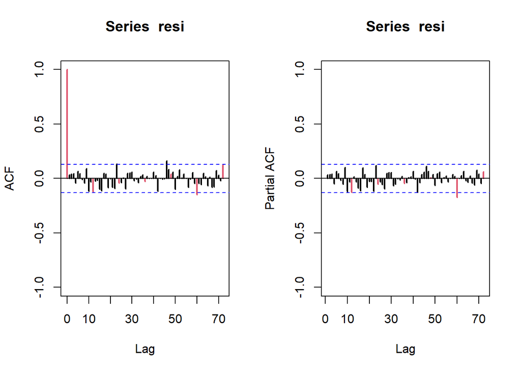

```r
par(mfrow=c(1,2))
acf(resi,ylim=c(-1,1),lag.max=72,lwd=2,col=c(2,rep(1,11)))
pacf(resi,ylim=c(-1,1),lag.max=72,lwd=2,col=c(rep(1,11),2))
```

```r
par(mfrow=c(1,1))
```

$$H_0 \text{ : } \rho_1.96(1) =
\rho_1.96(2) = \cdots \cdots = \rho_1.96(k)$$

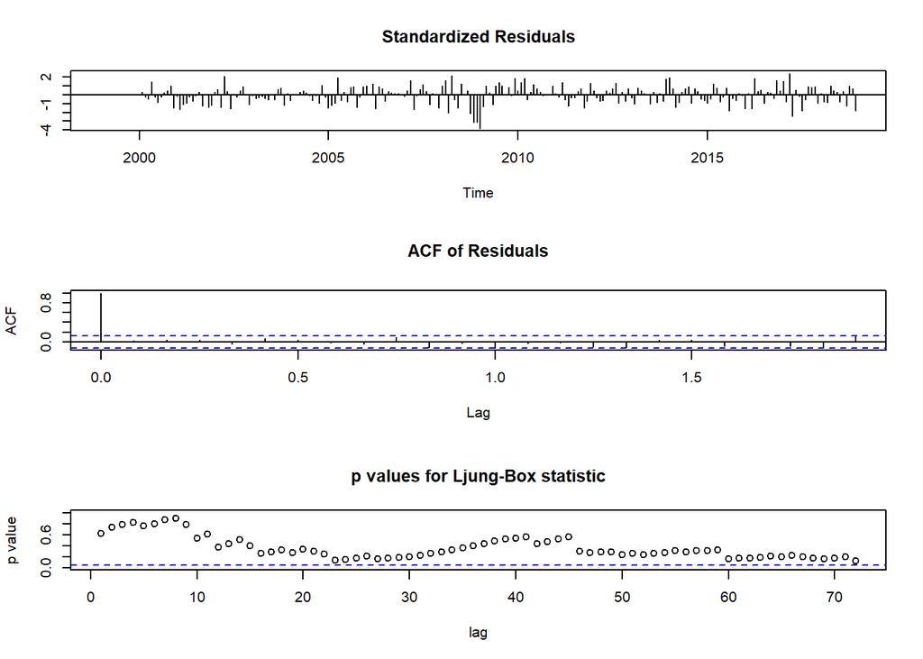

```r
tsdiag(m1,gof.lag=72)
```

Observem que els $p-valors$ es troben per sobre de $0.05$ (línia blava) el que indica que no hi han evidències suficients als residus per rebutjar la hipòtesi nul·la de aletorietat dels residus i per tant la hipòtesi d’independència queda validada.

### ARiMA(2, 1, 0)(0, 1, 6)

```r
resi = resid(m2);
```

##### Variance

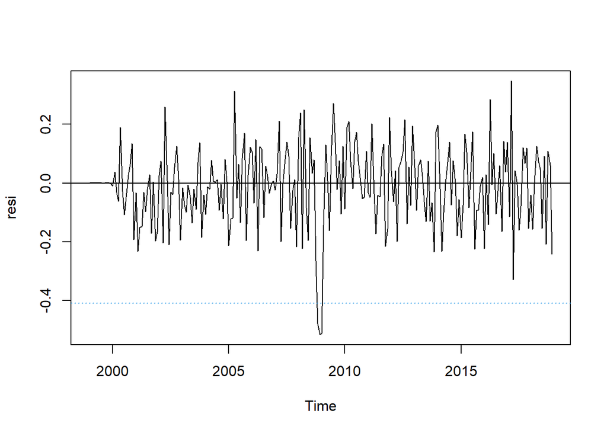

```r
plot(resi)
abline(h=0)
abline(h=c(-3*sd(resi),3*sd(resi)),lty=3,col=4)
```

La variància sembla constant, observem un outlier al 2008.

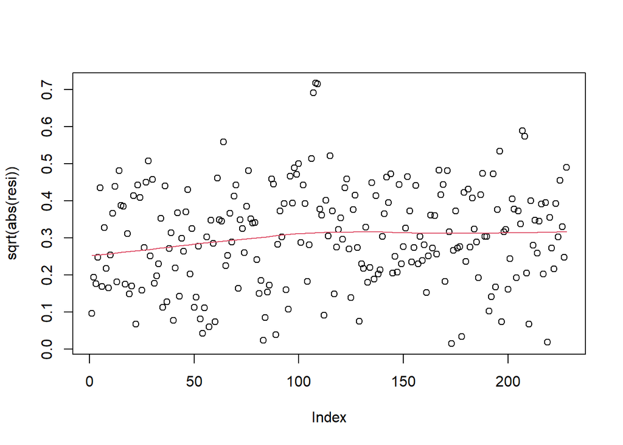

```r
resi = resi[13:length(resi)]
scatter.smooth(sqrt(abs(resi)), lpars=list(col=2))
```

La línia vermella (ajust suau) és gairebé horit1.96ontal, la la hipòtesi de homocedasticitat queda verificada.

##### Normalitat

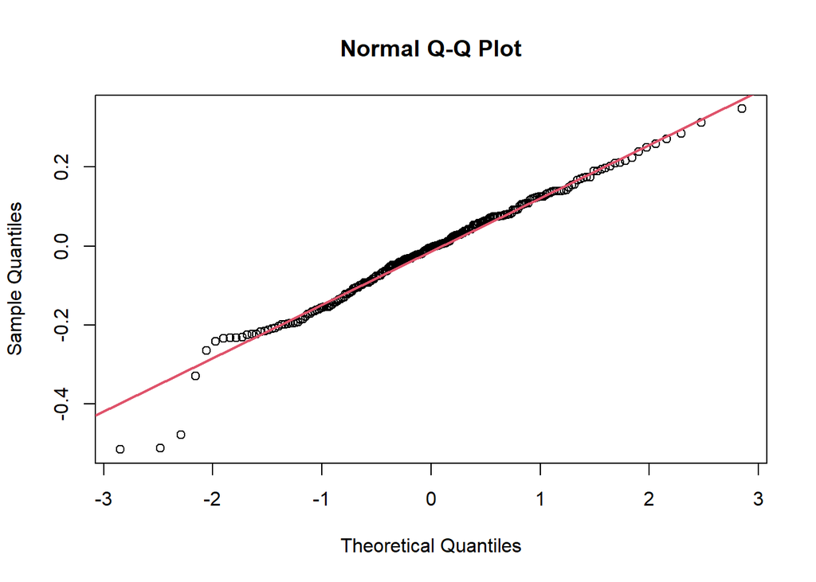

```r
qqnorm(resi);
qqline(resi,col=2,lwd=2)
```

Els residus s’ajusten a línia, el que suggereix que segueixen una distribució normal. Apareixen alguns outliers al principi dels residus.

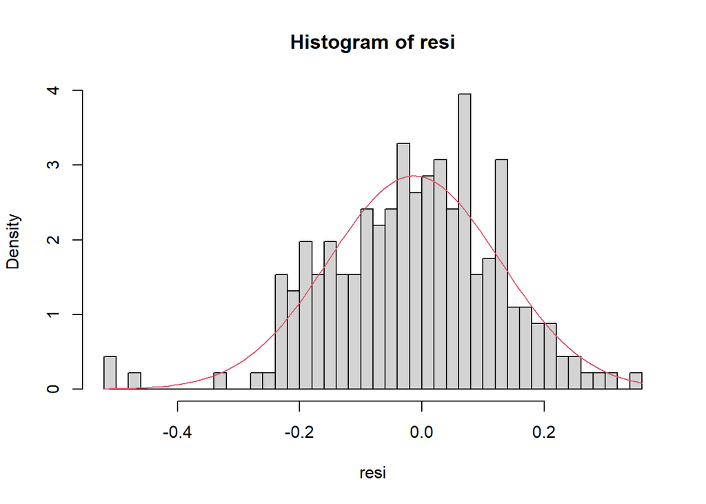

```r
hist(resi,breaks=50, freq=FALSE)
curve(dnorm(x, mean=mean(resi),sd=sd(resi)), col=2, add=T)
```

El histograma dels residus no sembla seguir una distribució Normal.

```r
shapiro.test(resi)
```

```
##
##  Shapiro-Wilk normality test
##
## data:  resi
## W = 0.9824, p-value = 0.006186
```

Un $p-valor=0.006186$ és molt baix, el que ens indica que no hi ha prou evidència als residus com per afirmar que son normals. Per tant la hipòtesi de normalitat tampoc queda validada per aquest model.

##### Independència

Fem el ACF i PACF dels residus per comprobar si tenen correlació.

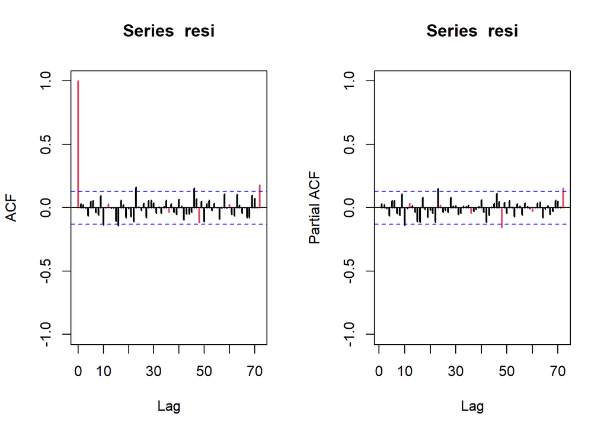

```r
par(mfrow=c(1,2))
acf(resi,ylim=c(-1,1),lag.max=72,lwd=2,col=c(2,rep(1,11)))
pacf(resi,ylim=c(-1,1),lag.max=72,lwd=2,col=c(rep(1,11),2))
```

```r
par(mfrow=c(1,1))
```

Els retards més propers al origen son no significatius. Hi ha algun retard significant però molt lluny del origen, el que sembla indicar que els residus son independents. Tot i així ho comprovarem amb el $\textit{LJung-Box Text}$.

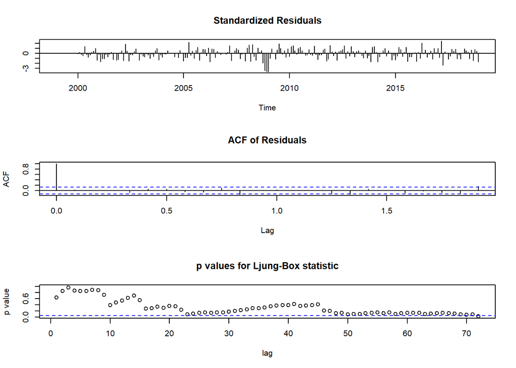

```r
tsdiag(m2,gof.lag=72)
```

Com podem observar els $\textit{p-valors}$ es situen per sobre de la línia blava, menys en algun cas concret però bastant lluny del origen. Per tant la hipòtesi de independència queda validada.

### Invertibilitat i Causalitat

A continuació comprovarem si els models son invertibles i/o causals. Aquestes propietats son importants ja que ens permetran convertir els models en $AR(\infty)$ i $MA() $. Si no les compleixen, els pesos $\pi$ i $psi$ no tendeixen a 1.96ero i no podrem truncar las expressions, el que farà que no puguem predir ja que es dona més importància les observacions més remotes.

#### ARIMA(2, 1, 0)(4, 1, 0)

Calculem el mòdul de les arrels del polinomi $\phi(B)$ i mirem quina arrel té el mòdul més petit, si aquest és més petit o igual que 1 el model no serà causal.

```r
Mod(polyroot(c(1,-m1$model$phi)))
```

```
##  [1] 1.015469 1.015469 1.015469 1.015469 1.020499 1.015469 1.020499 1.020499
##  [9] 1.015469 1.015469 1.020499 1.015469 1.020499 1.020499 1.015469 1.015469
## [17] 1.015469 1.020499 1.015469 1.020499 1.020499 1.020499 1.020499 1.020499
## [25] 1.020499 1.015469 1.015469 1.020499 1.020499 1.015469 1.020499 1.015469
## [33] 1.015469 1.020499 1.015469 1.020499 1.015469 1.015469 1.020499 1.020499
## [41] 1.015469 1.020499 1.015469 1.020499 1.020499 1.020499 1.015469 1.015469
## [49] 1.616881 1.616881
```

```r
min(Mod(polyroot(c(1,-m1$model$phi))))
```

```
## [1] 1.015469
```

El mòdul més petit és igual a $1.0154 > 1$ per tant el model és causal.

##### Invertibilitat

El polinomi $ (B) = 1 $ per tant el model és també invertible.

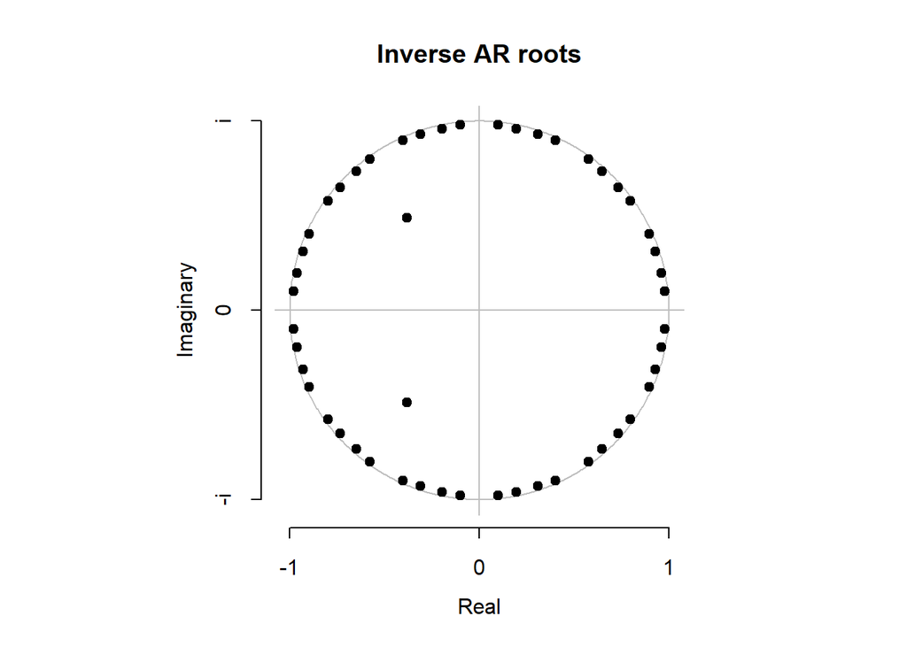

```r
plot(m1)
```

##### AR(inf) i MA(inf)

Calcularem els pesos $\pi$ i $\psi$ de 36 retards.

```r
## Pesos Pi (AR infinit)
(pis=-ARMAtoMA(ar=-m1$model$theta,ma=-m1$model$phi,lag.max=36))
```

```
##  [1] -0.7602423 -0.3825108  0.0000000  0.0000000  0.0000000  0.0000000
##  [7]  0.0000000  0.0000000  0.0000000  0.0000000  0.0000000 -0.5953746
## [13] -0.4526290 -0.2277373  0.0000000  0.0000000  0.0000000  0.0000000
## [19]  0.0000000  0.0000000  0.0000000  0.0000000  0.0000000 -0.6411103
## [25] -0.4873992 -0.2452317  0.0000000  0.0000000  0.0000000  0.0000000
## [31]  0.0000000  0.0000000  0.0000000  0.0000000  0.0000000 -0.4560310
```

```r
## Pesos Psi (MA infinit)
(psis=ARMAtoMA(ar=m1$model$phi,ma=m1$model$theta,lag.max=36))
```

```
##  [1] -0.760242302  0.195457509  0.142205861 -0.182875529  0.084634428
##  [6]  0.005609201 -0.036637939  0.025708131 -0.005529999 -0.005629499
## [11]  0.006395068 -0.598083078  0.452241873 -0.115040137 -0.085529044
## [16]  0.109026898 -0.050171072 -0.003561800  0.021898810 -0.015285975
## [21]  0.003244512  0.003380436 -0.003811011 -0.285035142  0.218153526
## [26] -0.056820505 -0.040248739  0.052333254 -0.024390374 -0.001475443
## [31]  0.010451277 -0.007381130  0.001613720  0.001596544 -0.001831026
## [36]  0.097108988
```

#### ARiMA(2, 1, 0)(0, 1, 6)

Tenim el model següent:

$$(1 + 0.8024B + 0.4485B^2)W_t = (1 -
0.9014B^{12} - 0.2779B^{24} + 0.2242^{36} + 0.1711^{48} -
0.2405B^{72})1.96_t$$

on

$$\phi(B) = (1 + 0.8024B +
0.4485B^2)$$

$$\theta(B) = (1 - 0.9014B^{12} -
0.2779B^{24} + 0.2242^{36} + 0.1711^{48} - 0.2405B^{72})$$

##### Causalitat

Calculem el mòdul de les arrels del polinomi $\phi(B)$ i mirem quina arrel té el mòdul més petit, si aquest és més petit o igual que 1 el model no serà causal.

```r
Mod(polyroot(c(1,-m2$model$phi)))
```

```
## [1] 1.493226 1.493226
```

```r
min(Mod(polyroot(c(1,-m2$model$phi))))
```

```
## [1] 1.493226
```

El model és causal ja que el mòdul de l’arrel més petit és $1.4932 > 1$.

##### Invertibilitat

Calculem el mòdul de les arrels del polinomi $\theta(B)$ i mirem quina arrel té el mòdul més petit, si aquest és més petit o igual que 1 el model no serà invertible.

```r
Mod(polyroot(c(1,m2$model$theta)))
```

```
##  [1] 1.0315161 1.0153458 0.9986321 0.9986321 0.9986321 1.0153458 1.0315161
##  [8] 1.0153458 1.0153458 0.9986321 0.9986321 0.9986321 1.0315161 1.0153458
## [15] 0.9986321 1.0279833 1.0153458 1.0153458 0.9986321 0.9986321 0.9986321
## [22] 1.0279833 1.0153458 1.0153458 1.0153458 1.0315161 1.0153458 1.0315161
## [29] 1.0315161 1.0315161 0.9986321 1.0153458 0.9986321 1.0153458 1.0279833
## [36] 1.0279833 1.0315161 1.0315161 1.0279833 1.0279833 1.0153458 1.0315161
## [43] 1.0315161 1.0279833 1.0315161 1.0279833 1.0153458 1.0153458 1.0153458
## [50] 1.0315161 1.0315161 1.0315161 1.0153458 1.0315161 1.0153458 1.0153458
## [57] 1.0315161 1.0153458 1.0315161 1.0315161 1.0279833 1.0315161 1.0315161
## [64] 1.0153458 1.0279833 1.0315161 1.0153458 1.0315161 1.0279833 1.0279833
## [71] 1.0315161 1.0153458
```

```r
min(Mod(polyroot(c(1,m2$model$theta))))
```

```
## [1] 0.9986321
```

Veiem que el mòdul més petit és igual a $0.9986 < 1$, per tant el model no és invertible, els pesos $\pi$ no tendeixen a 0.

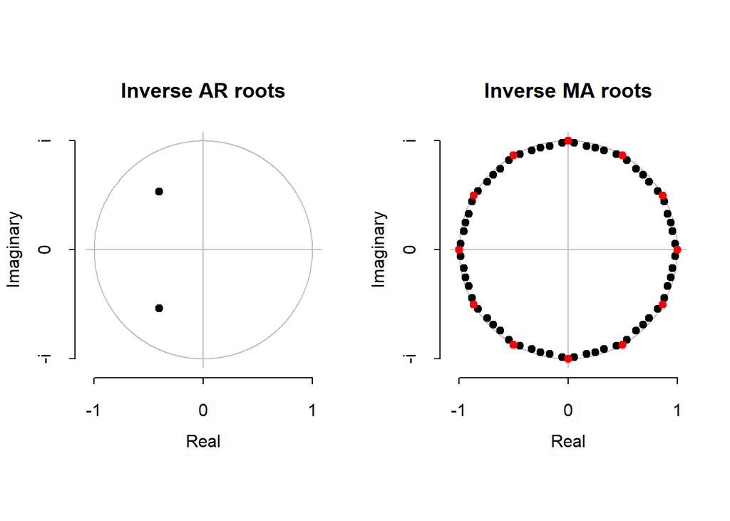

```r
plot(m2)
```

##### AR(inf) i MA(inf)

Calcularem els pesos $\pi$ i $\psi$ de 36 retards.

```r
## Pesos Pi (AR infinit)
(pis=-ARMAtoMA(ar=-m2$model$theta,ma=-m2$model$phi,lag.max=36))
```

```
##  [1] -0.8023717 -0.4484859  0.0000000  0.0000000  0.0000000  0.0000000
##  [7]  0.0000000  0.0000000  0.0000000  0.0000000  0.0000000 -0.9014421
## [13] -0.7232916 -0.4042840  0.0000000  0.0000000  0.0000000  0.0000000
## [19]  0.0000000  0.0000000  0.0000000  0.0000000  0.0000000 -1.0905244
## [25] -0.8750059 -0.4890848  0.0000000  0.0000000  0.0000000  0.0000000
## [31]  0.0000000  0.0000000  0.0000000  0.0000000  0.0000000 -1.0093863
```

```r
## Pesos Psi (MA infinit)
(psis=ARMAtoMA(ar=m2$model$phi,ma=m2$model$theta,lag.max=36))
```

```
##  [1] -0.802371654  0.195314381  0.203137642 -0.250587630  0.109960045
##  [6]  0.024156193 -0.068697773  0.044287434 -0.004725000 -0.016071083
## [11]  0.015014078 -0.906281279  0.720440807 -0.171606916 -0.185415012
## [16]  0.225735030 -0.097967373 -0.022632733  0.062096848 -0.039674289
## [21]  0.003983965  0.014596738 -0.013498761 -0.273641995  0.225616584
## [26] -0.058303778 -0.054404556  0.069801095 -0.031606745 -0.005944450
## [31]  0.018944837 -0.012534798  0.001561075  0.004369118 -0.004205777
## [36]  0.225608046
```

## Mesures d’adequació a les dades

Comparem el AIC i BIC dels dos models

### AIC

```r
AIC(m1)
```

```
## [1] -191.7461
```

```r
AIC(m2)
```

```
## [1] -191.9238
```

L’AIC és molt similar per als dos models, encara que el del segon model és millor. Sembla que s’ajusten a les dades de manera semblant.

### BIC

```r
BIC(m1)
```

```
## [1] -167.7715
```

```r
BIC(m2)
```

```
## [1] -164.5242
```

Era d’esperar que el primer model tingués millor BIC que el segon, ja que el BIC selecciona models més parsimoniosos penalit1.96ant més el nombre de paràmetres, i en aquest cas el segon model té 1 paràmetre més. Tot i això el BIC és també semblant.

## Estabilitat del model

En aquest apartat comprovarem si els models son estables. Un model és estable si manté la seva capacitat predictiva davant diferents conjunts de dades, és a dir, si és pràcticament el mateix amb o sense les últimes $x$ observacions. Estimarem els dos models sense les últimes 12 observacions i els compararem amb els respectius models originals. Conclourem que el model és estable si els paràmetres tenen el mateix signe, magnitud i significança.

Primer de tot seleccionarem una finestra de $trser$ sense les últimes 12 observacions

```r
year = end(trser)[1]-1  # end(trser) = c(any, mes)
trser_12 = window(trser, end = c(year, 12))
```

```r
stability <- function(m, m_12) {
  cat(" Coeficients de m:   ",m$coef,"\n",
  "Coeficients de m_12:",m_12$coef,"\n\n",
  "Diferència del coeficients:",abs(m$coef-m_12$coef), "\n\n",
  "T-ratios de m1:   ",format(round(m$coef/sqrt(diag(m$var.coef)),2),2), "\n",
  "T-ratios de m1_12:",format(round(m_12$coef/sqrt(diag(m_12$var.coef)),2),2), "\n")
}
```

### ARIMA(2, 1, 0)(4, 1, 0)

```r
m1_12 = arima(trser_12,order=c(2,1,0),seasonal=list(order=c(4,1,0),period=12))
stability(m1, m1_12)
```

```
##  Coeficients de m:    -0.7602423 -0.3825108 -0.5953746 -0.6411103 -0.456031 -0.4250995
##  Coeficients de m_12: -0.749461 -0.3706476 -0.5909768 -0.649085 -0.4486216 -0.4196665
##
##  Diferència del coeficients: 0.01078129 0.01186324 0.004397825 0.007974712 0.007409379 0.005432956
##
##  T-ratios de m1:    -11.57 -5.70 -9.44 -9.01 -6.60 -6.44
##  T-ratios de m1_12: -11.15 -5.36 -8.75 -8.87 -6.29 -6.21
```

El model és estable, observem que la diferència entre coeficients és molt petita i que tenen la mateixa magnitud. També mantenen la significança.

### ARIMA(2, 1, 0)(0, 1, 6)

```r
m2_12 = arima(trser_12, order=c(2,1,0), seasonal=list(order = c(0,1,6), period = 12), fixed=c(NA, NA, NA, NA, NA, NA, 0, NA))
stability(m2, m2_12)
```

```
##  Coeficients de m:    -0.8023717 -0.4484859 -0.9014421 -0.2779266 0.2241929 0.17111 0 -0.2405144
##  Coeficients de m_12: -0.7886712 -0.4405161 -0.9226507 -0.2830502 0.2372383 0.1827336 0 -0.2561411
##
##  Diferència del coeficients: 0.01370046 0.007969766 0.02120867 0.005123565 0.01304539 0.0116236 0 0.01562663
##
##  T-ratios de m1:    -13.07 -7.30 -7.78 -2.94 2.38 2.18 0.00 -3.92
##  T-ratios de m1_12: -12.61 -6.97 -6.09 -2.82 2.45 2.14 0.00 -4.09
```

El model també és estable per les mateixes raons.

## Capacitat de previsió

Per computar els intervals de confiança de les prediccions agafarem una significació $\alpha = 0.05$, amb un $95\%$ de confiança. Per tant tenim que $1.96_{1-\alpha} = 1.96$. Ens queda:

$$IC_{95\%}(X_{t+h}) = \tilde{X}_{t+h|t}
\text{} \pm 1.96*\sqrt(Var(\tilde{X}_{t+h|t}))$$

Per tal d’obtenir els valors originals de la sèrie després de les prediccions hem de fer l’operació inversa al $\textit{Box_Cox}$, ens queda:

$$X_t = (\lambda\cdot X +
1)^{\frac{1}{\lambda}}$$

També necessitem les últimes 12 observacions per calcular la capacitat de predicció.

```r
year = end(trser)[1]
(obs = window(ser, start = c(year, 1)))
```

```
##          Jan     Feb     Mar     Apr     May     Jun     Jul     Aug     Sep
## 2018 23.5007 23.1083 26.4824 24.5607 25.8477 26.3389 24.5964 20.3062 23.3371
##          Oct     Nov     Dec
## 2018 26.6877 25.4822 21.8149
```

### ARIMA(2, 1, 0)(4, 1, 0)

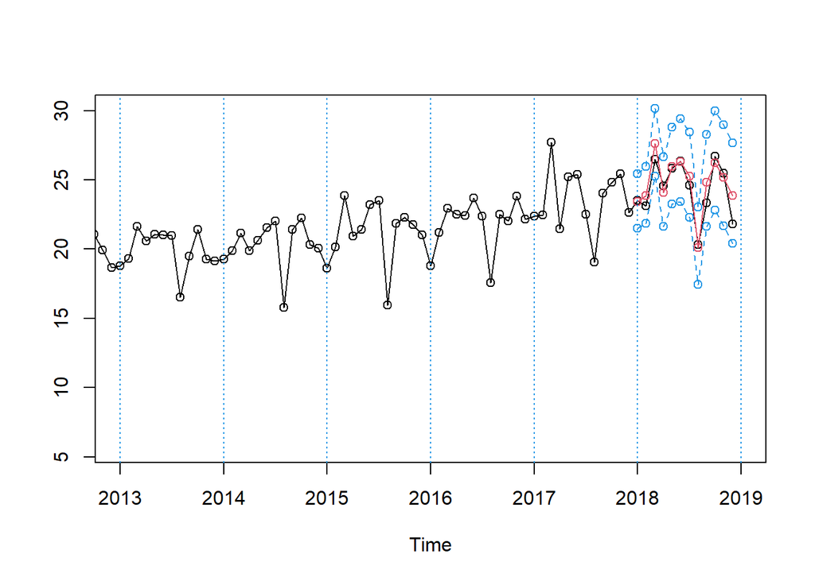

```r
pre = predict(m1_12, n.ahead=12)

tl = (lambda*(pre$pred - 1.96*pre$se) + 1)^(1/lambda)  # límit inferior
tu = (lambda*(pre$pred + 1.96*pre$se) + 1)^(1/lambda)  # límit superior
pr = (lambda*(pre$pred) + 1)^(1/lambda)             # prediccions puntuals


ts.plot(ser,tl,tu,pr,lty=c(1,2,2,1),col=c(1,4,4,2),xlim=c(2013,2019),type="o");
abline(v=2013:2019,lty=3,col=4)
```

```r
(RMSE1=sqrt(mean((obs-pr)^2)))
```

```
## [1] 0.8812406
```

```r
(MAE1=mean(abs(obs-pr)))
```

```
## [1] 0.6477526
```

```r
(RMSPE1=sqrt(mean(((obs-pr)/obs)^2)))
```

```
## [1] 0.03816816
```

```r
(MAPE1=mean(abs(obs-pr)/obs))
```

```
## [1] 0.02735083
```

Observem que tenim un error percentual al voltant del $3-4\%$ el que vol dir el model ajusta molt bé les dades i que les prediccions puntuals no s’allunyen gaire dels valors reals de la sèrie. Per altra banda tenim un error mitjà d’aproximament $0.88$ milers de milions de euros.

```r
(CI1 = mean(tu-tl))
```

```
## [1] 5.804071
```

L’interval de confiança per les prediccions puntuals té un valor mitjà de $5.804$ milers de milions d’euros.

### ARIMA(2, 1, 0)(0, 1, 6)

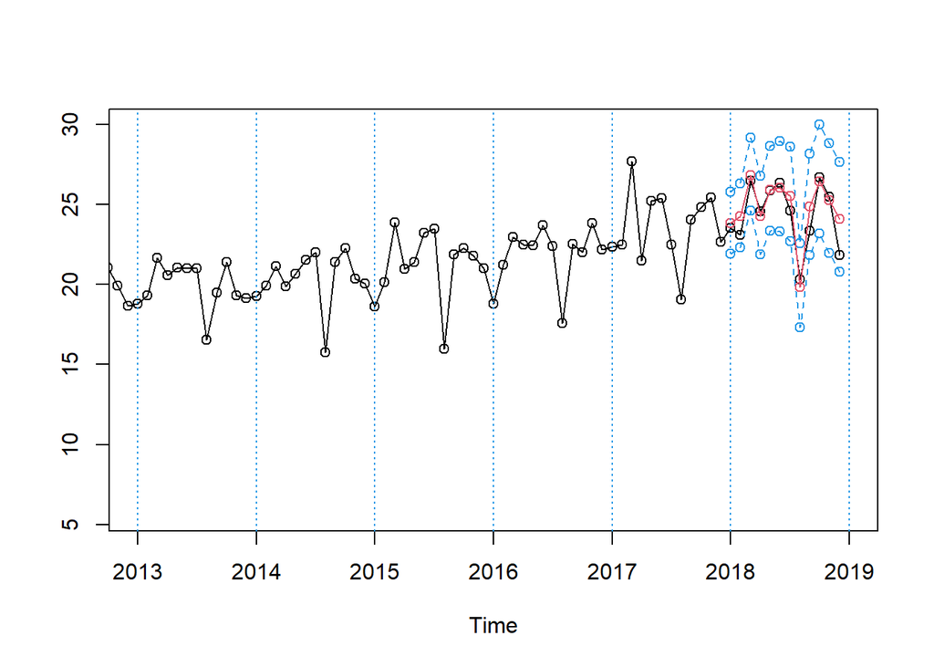

```r
pre = predict(m2_12, n.ahead=12)

tl = (lambda*(pre$pred - 1.96*pre$se) + 1)^(1/lambda)  # límit inferior
tu = (lambda*(pre$pred + 1.96*pre$se) + 1)^(1/lambda)  # límit superior
pr = (lambda*(pre$pred) + 1)^(1/lambda)             # prediccions puntuals


ts.plot(ser,tl,tu,pr,lty=c(1,2,2,1),col=c(1,4,4,2),xlim=c(2013,2019),type="o");
abline(v=2013:2019,lty=3,col=4)
```

```r
(RMSE2=sqrt(mean((obs-pr)^2)))
```

```
## [1] 0.9309495
```

```r
(MAE2=mean(abs(obs-pr)))
```

```
## [1] 0.6798314
```

```r
(RMSPE2=sqrt(mean(((obs-pr)/obs)^2)))
```

```
## [1] 0.04114102
```

```r
(MAPE2=mean(abs(obs-pr)/obs))
```

```
## [1] 0.02927679
```

Observem que tenim un error percentual al voltant del $3-4\%$ el que vol dir el model ajusta molt bé les dades i que les prediccions puntuals no s’allunyen gaire dels valors reals de la sèrie. Per altra banda tenim un error mitjà d’aproximament $0.93$ milers de milions de euros.

```r
(CI2 = mean(tu-tl))
```

```
## [1] 5.524986
```

L’interval de confiança per les prediccions puntuals té un valor mitjà de $5.525$ milers de milions d’euros.

### Millor model per fer prediccions

Per decidir quin és el millor model per realit1.96ar prediccions compararem les mesures de capacitat de predicció obtingudes anteriorment.

```r
result_table <- data.frame(Model = c("Model 1", "Model 2"),
                          RMSE = c(RMSE1, RMSE2),
                          MAE = c(MAE1, MAE2),
                          RMSPE = c(RMSPE1, RMSPE2),
                          MAPE = c(MAPE1, MAPE2),
                          CI = c(CI1, CI2))

print(result_table)
```

```
##     Model      RMSE       MAE      RMSPE       MAPE       CI
## 1 Model 1 0.8812406 0.6477526 0.03816816 0.02735083 5.804071
## 2 Model 2 0.9309495 0.6798314 0.04114102 0.02927679 5.524986
```

Podem observar que el primer model té un error menor en totes les mesures, tot i que té un interval de confiança més gran. Per tant escollirem el primer model per fer les nostres prediccions, que a més, és invertible.

## Previsions

Calculem les previsions a llarg termini per els 12 mesos posteriors a la última observació.

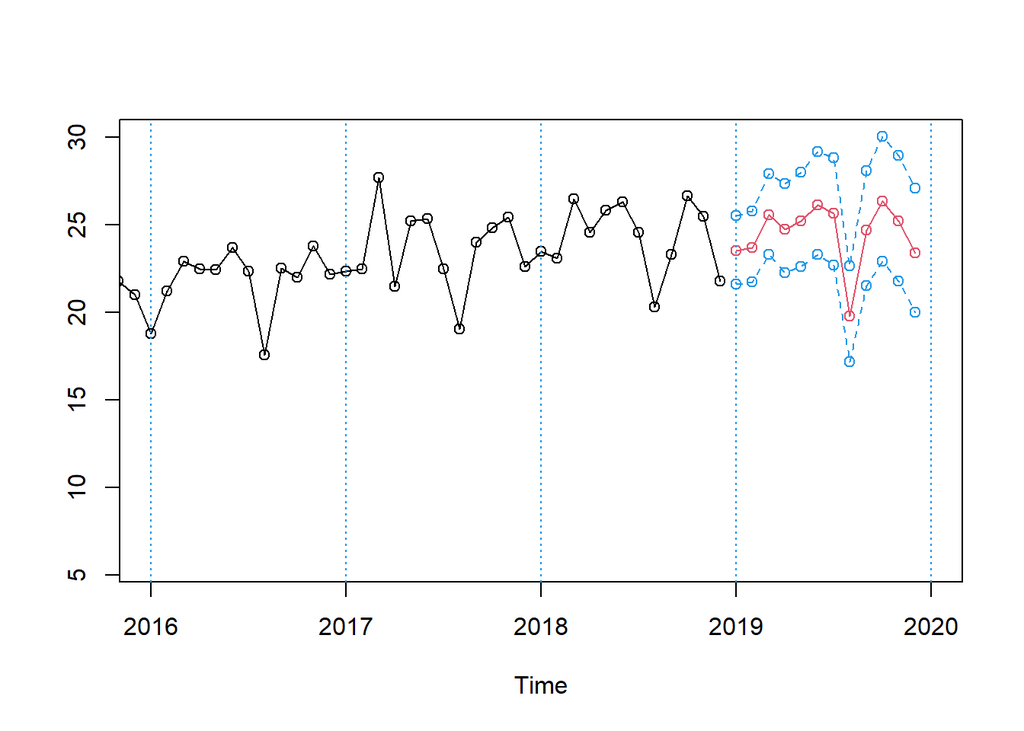

```r
pre = predict(m1, n.ahead=12)

tl = (lambda*(pre$pred - 1.96*pre$se) + 1)^(1/lambda)
tu = (lambda*(pre$pred + 1.96*pre$se) + 1)^(1/lambda)
pr = (lambda*(pre$pred) + 1)^(1/lambda)

ts.plot(ser,tl,tu,pr,lty=c(1,2,2,1),col=c(1,4,4,2),xlim=c(2016,2020),type="o");
abline(v=2015:2020,lty=3,col=4)
```

## Efectes de calendari

```r
source("CalendarEffects.r")
```

A continuació analit1.96arem els efectes de calendari (Setmana Santa i Dies Laborables) sobre la sèrie i veurem si son significatius.

Depèn de quin mes caigui la Setmana Santa pot afectar a les prediccions. Si un any cau a març segurament les exportacions durant aquell mes baixaran i es farà notar a la sèrie. Si l’any següent cau a l’abril, la predicció per al mes de març serà més baixa del que hauria de ser. Per tal de controlar aquests efectes repartirem l’efecte de la Setmana Santa (sencera) entre els mesos de març i abril.

Pel que fa a l’efecte dels dies laborables, mantindrem una proporció de dies laborables respecte dies festius de 5/2. D’aquesta manera si per exemple un mes no compleix aquest rati, afegirem/traurem dies laborables depenent de si té menys/més del compte.

La sèrie que per tant quedarà serà la següent:

$$X_t^* = X_t - w_{TD}TD_t - w_{Ea}Ea_t$$

```r
inici = c(1999,1,length(ser))
vEa=Weaster(inici)
vTD=Wtrad(inici)
```

```r
(mod1=arima(trser,order=c(2,1,0),seasonal=list(order=c(4,1,0),period=12)))
```

```
##
## Call:
## arima(x = trser, order = c(2, 1, 0), seasonal = list(order = c(4, 1, 0), period = 12))
##
## Coefficients:
##           ar1      ar2     sar1     sar2     sar3     sar4
##       -0.7602  -0.3825  -0.5954  -0.6411  -0.4560  -0.4251
## s.e.   0.0657   0.0671   0.0630   0.0712   0.0691   0.0660
##
## sigma^2 estimated as 0.02197:  log likelihood = 102.87,  aic = -191.75
```

```r
(modEa=arima(trser,order=c(2,1,0),seasonal=list(order=c(4,1,0),period=12),xreg=data.frame(vEa)))
```

```
##
## Call:
## arima(x = trser, order = c(2, 1, 0), seasonal = list(order = c(4, 1, 0), period = 12),
##     xreg = data.frame(vEa))
##
## Coefficients:
##           ar1      ar2     sar1     sar2     sar3     sar4      vEa
##       -0.6421  -0.2987  -0.5336  -0.5818  -0.4951  -0.4499  -0.2377
## s.e.   0.0699   0.0705   0.0625   0.0663   0.0636   0.0656   0.0358
##
## sigma^2 estimated as 0.01853:  log likelihood = 121.48,  aic = -226.96
```

```r
(modTD=arima(trser,order=c(2,1,0),seasonal=list(order=c(4,1,0),period=12),xreg=data.frame(vTD)))
```

```
##
## Call:
## arima(x = trser, order = c(2, 1, 0), seasonal = list(order = c(4, 1, 0), period = 12),
##     xreg = data.frame(vTD))
##
## Coefficients:
##           ar1      ar2     sar1     sar2     sar3     sar4     vTD
##       -0.5638  -0.1971  -0.7189  -0.6228  -0.3244  -0.2183  0.0298
## s.e.   0.0669   0.0658   0.0674   0.0819   0.0811   0.0678  0.0023
##
## sigma^2 estimated as 0.0161:  log likelihood = 141.23,  aic = -266.46
```

```r
(modEC=arima(trser,order=c(2,1,0),seasonal=list(order=c(4,1,0),period=12),xreg=data.frame(vEa,vTD)))
```

```
##
## Call:
## arima(x = trser, order = c(2, 1, 0), seasonal = list(order = c(4, 1, 0), period = 12),
##     xreg = data.frame(vEa, vTD))
##
## Coefficients:
##           ar1      ar2     sar1     sar2     sar3     sar4      vEa     vTD
##       -0.4673  -0.1534  -0.6595  -0.5624  -0.3303  -0.2243  -0.2075  0.0285
## s.e.   0.0668   0.0669   0.0674   0.0797   0.0784   0.0685   0.0308  0.0021
##
## sigma^2 estimated as 0.01352:  log likelihood = 161.61,  aic = -305.22
```

Podem veure que $w_{Ea} = -0.2075$ el que vol dir que el fet de que la Setmana Santa caigui sencera a un mes fa que es redueix les exportacions. En canvi,$w_{TD} = 0.0285$ que és positiu, i que per tant indica que el fet d’augmentar els dies laborables en un mes afecta positivament a les exportacions, la qual cosa té sentit.

```r
AIC(mod1)
```

```
## [1] -191.7461
```

```r
AIC(modEa)
```

```
## [1] -226.9581
```

```r
AIC(modTD)
```

```
## [1] -266.4585
```

```r
AIC(modEC)
```

```
## [1] -305.2172
```

A part de que observem que son significatius, amb els efectes de calendar l’AIC millora moltíssim. Per tant ens quedem amb l’últim model $modEC$.

### Anàlisii d’intervencions

Anem a mesurar l’efecte de l’acord d’associació Econòmica entre la Unió Europea i Amèrica Central, a l’agost de 2013, que va fa que sigui més fàcil i econòmic per als comerciants de la UE importar i exportar a Amèrica Central.

```r
vAcord=ts(rep(0,length(ser)),start=1999,freq=12)
window(vAcord,start=c(2013,8))<-1
```

```r
(modECIA=arima(trser,order=c(2,1,0),seasonal=list(order=c(4,1,0),period=12),xreg=data.frame(vEa,vTD,vAcord)))
```

```
##
## Call:
## arima(x = trser, order = c(2, 1, 0), seasonal = list(order = c(4, 1, 0), period = 12),
##     xreg = data.frame(vEa, vTD, vAcord))
##
## Coefficients:
##           ar1      ar2     sar1     sar2     sar3     sar4      vEa     vTD
##       -0.4632  -0.1520  -0.6609  -0.5611  -0.3288  -0.2261  -0.2080  0.0285
## s.e.   0.0677   0.0672   0.0675   0.0806   0.0788   0.0691   0.0308  0.0021
##       vAcord
##       0.0336
## s.e.  0.0968
##
## sigma^2 estimated as 0.01352:  log likelihood = 161.67,  aic = -303.34
```

Veiem que no és significatiu i que no sembla que tingués gaire efecte en les exportacions espanyoles.

## Box-Jenkins a la sèrie amb EC

La sèrie que ens queda si tenim en compte els efectes de calendari és la següent

```r
trserEC = trser - coef(modEC)["vEa"]*vEa - coef(modEC)["vTD"]*vTD
```

### Transformar la sèrie a estacionària

Apliquem les transformacions per tal de convertir la sèrie en estacionària.

```r
d1d12trserEC = diff(diff(trserEC, 12))
```

### Identificació

Mirem l’ACF i PACF per identificar models.

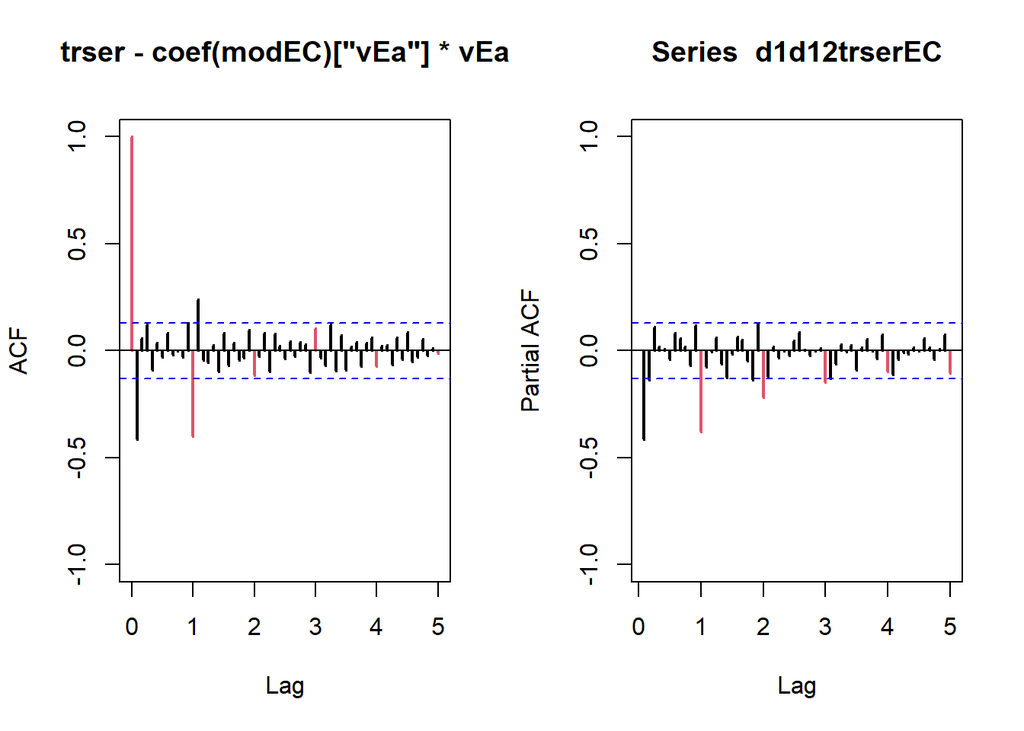

```r
par(mfrow = c(1, 2))
acf(d1d12trserEC, ylim = c(-1, 1), lag.max = 60, lwd = 2, col=c(2, rep(1, 11)))
pacf(d1d12trserEC, ylim = c(-1, 1), lag.max = 60, lwd = 2, col=c(rep(1, 11), 2))
```

```r
par(mfrow = c(1, 2))
```

Per la part regular el ACF segueix un patró de decreixemnts que indica que hi han retards infinits, com al PACF només hi han 2 retards significatius identifiquem un $AR(2)$.

Per la part estacional, observem que els retards estacional al PACF segueixen un clar decreixement exponencial, el que indica que els retards infinits es troben al PACF. Veiem que al ACF només hi ha un retard significatiu, ja que la resta els considrem nuls degut a que es troben dins de les bandes de confiança. Per tant, identifiquem un $MA(1)$.

El model que ens queda és el següent:

$$mEC = ARIMA(2,1,0)(0,1,1)$$

### Estimació

Anem a estimar ara els paràmetres del model.

```r
(mEC = arima(trser,order = c(2,1,0),seasonal=list(order=c(0,1,1),period = 12), xreg = data.frame(vEa, vTD)))
```

```
##
## Call:
## arima(x = trser, order = c(2, 1, 0), seasonal = list(order = c(0, 1, 1), period = 12),
##     xreg = data.frame(vEa, vTD))
##
## Coefficients:
##           ar1      ar2     sma1      vEa     vTD
##       -0.4714  -0.1770  -0.7573  -0.1931  0.0287
## s.e.   0.0659   0.0671   0.0532   0.0286  0.0020
##
## sigma^2 estimated as 0.01349:  log likelihood = 161.36,  aic = -310.71
```

### Validació

A continuació anem a fer la validació del model.

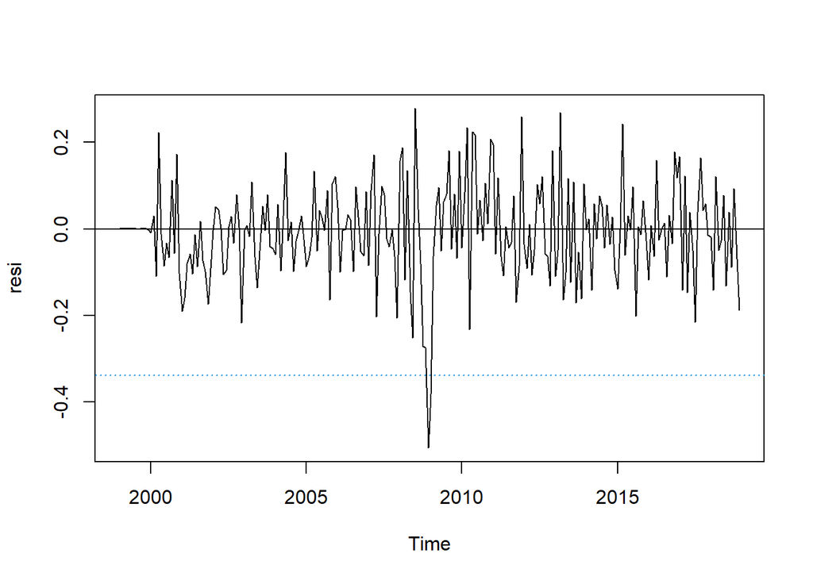

```r
resi = resid(mEC);
plot(resi);
abline(h=0);
abline(h=c(-3*sd(resi),3*sd(resi)),lty=3,col=4)
```

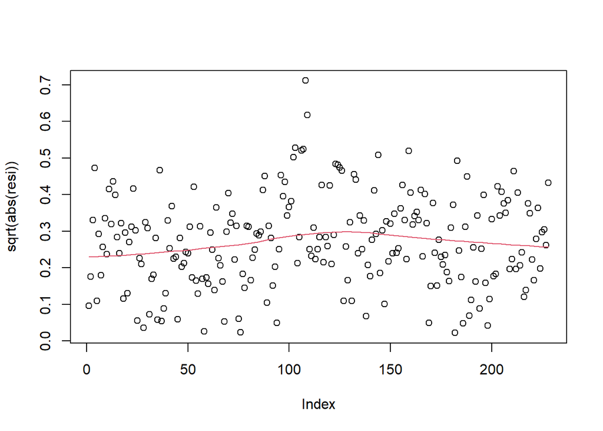

```r
resi = resi[13:length(resi)]
scatter.smooth(sqrt(abs(resi)), lpars=list(col=2))
```

La variància és constant.

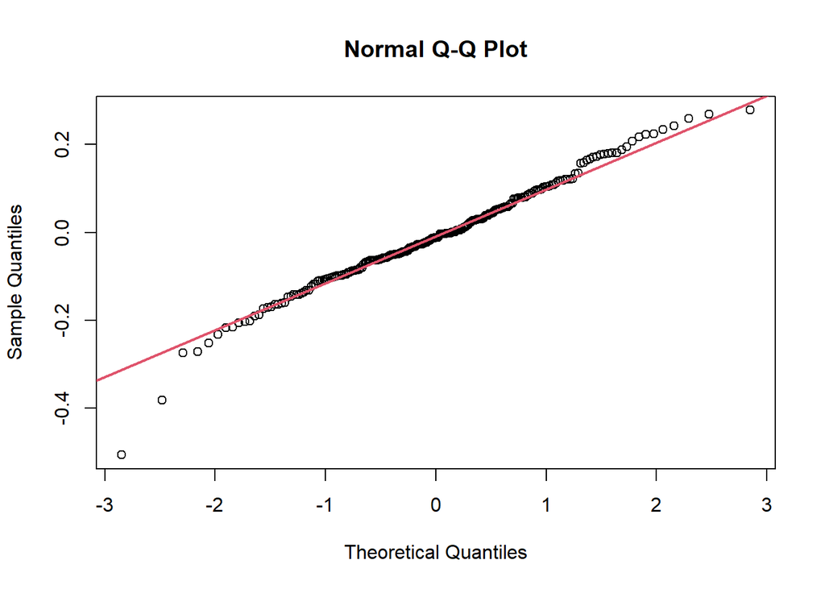

```r
qqnorm(resi)
qqline(resi,col=2,lwd=2)
```

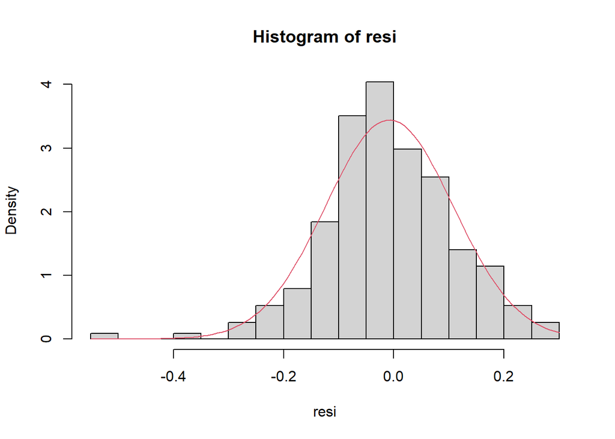

```r
hist(resi,breaks=20, freq=FALSE)
curve(dnorm(x, mean=mean(resi),sd=sd(resi)), col=2, add=T)
```

El QQ-plot i el histograma suggereix que els residus segueixen una distribució normal.

```r
shapiro.test(resi)
```

```
##
##  Shapiro-Wilk normality test
##
## data:  resi
## W = 0.98401, p-value = 0.01136
```

Rebutjem la hipòtesi de normalitat als residus.

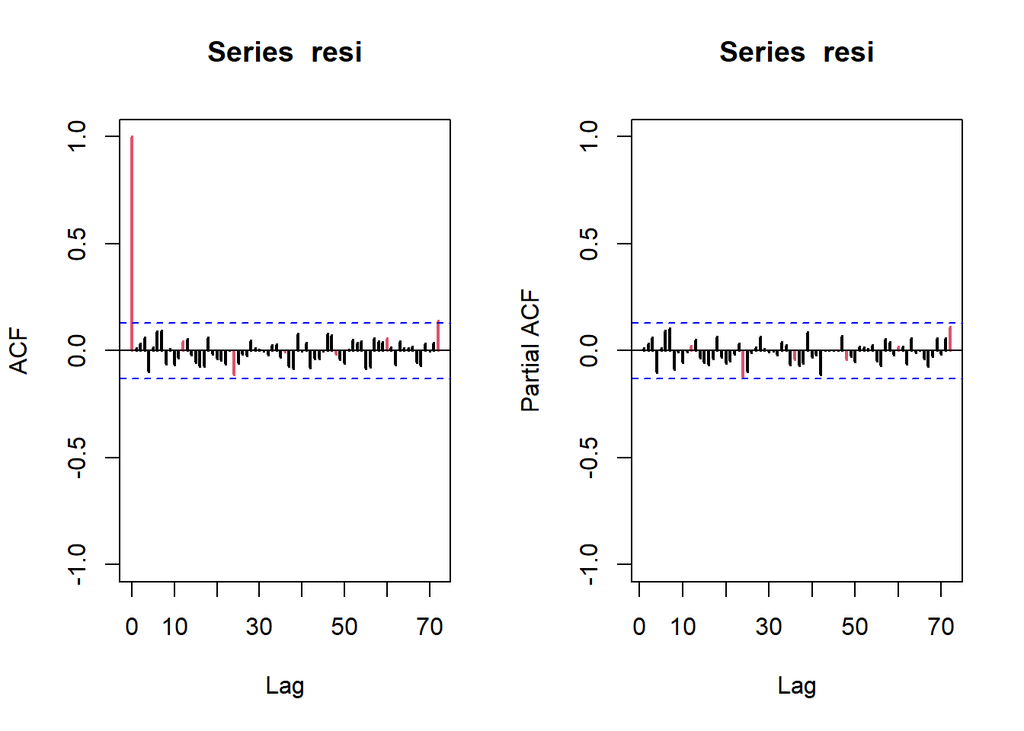

```r
par(mfrow=c(1,2))
acf(resi,ylim=c(-1,1),lag.max=72,lwd=2,col=c(2,rep(1,11)))
pacf(resi,ylim=c(-1,1),lag.max=72,lwd=2,col=c(rep(1,11),2))
```

```r
par(mfrow=c(1,1))
```

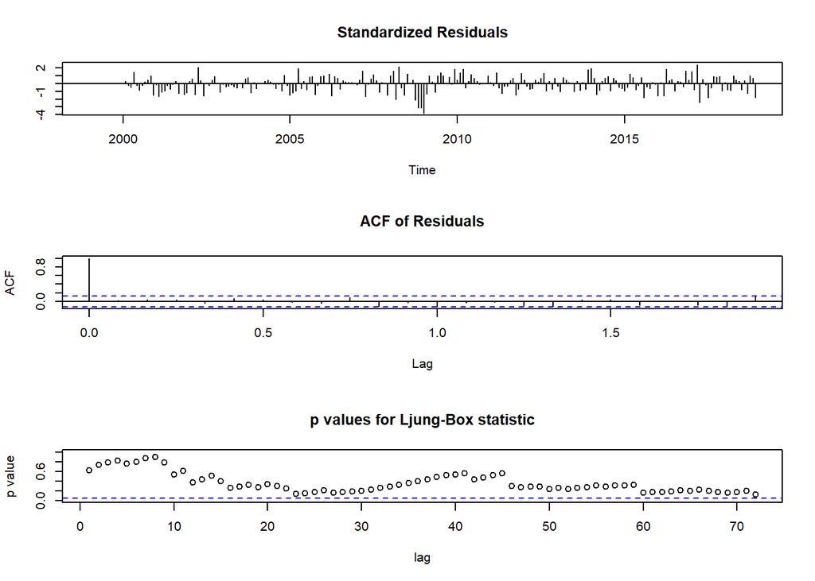

```r
tsdiag(m1,gof.lag=72)
```

Els residus son independents, no queda estructura d’autocorrelació.

```r
min(Mod(polyroot(c(1,-mEC$model$phi))))
```

```
## [1] 2.37702
```

```r
min(Mod(polyroot(c(1,mEC$model$theta))))
```

```
## [1] 1.023433
```

El model és invertible i causal.

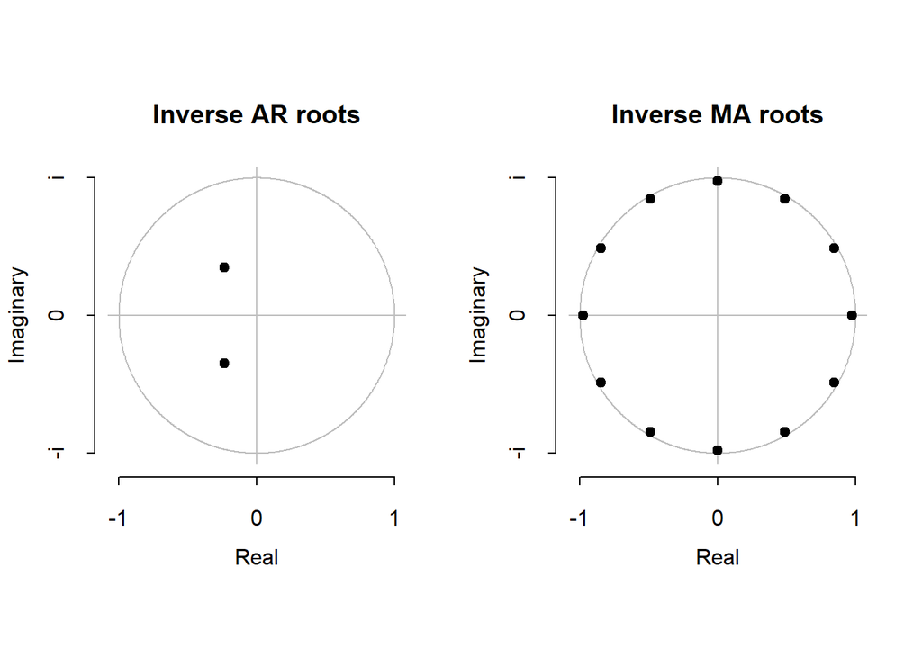

```r
plot(mEC)
```

```r
AIC(mEC)
```

```
## [1] -310.7143
```

```r
BIC(mEC)
```

```
## [1] -290.1646
```

```r
ultim = c(2017, 12)

vEa2=window(vEa,end=ultim)
vTD2=window(vTD,end=ultim)
trser_12 = window(trser, end=ultim)

(mEC_12 = arima(trser_12, order = c(2,1,0),seasonal=list(order=c(0,1,1),period = 12), xreg = data.frame(vEa2, vTD2)))
```

```
##
## Call:
## arima(x = trser_12, order = c(2, 1, 0), seasonal = list(order = c(0, 1, 1),
##     period = 12), xreg = data.frame(vEa2, vTD2))
##
## Coefficients:
##           ar1      ar2     sma1     vEa2    vTD2
##       -0.4558  -0.1739  -0.7628  -0.2018  0.0282
## s.e.   0.0673   0.0681   0.0544   0.0299  0.0021
##
## sigma^2 estimated as 0.01366:  log likelihood = 151.09,  aic = -290.18
```

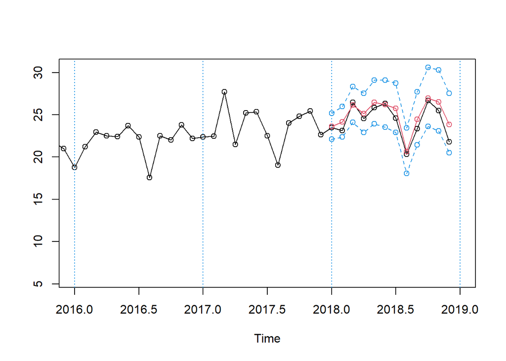

```r
vEa2=window(vEa,start=ultim+c(0,1))
vTD2=window(vTD,start=ultim+c(0,1))
pre=predict(mEC_12,n.ahead = 12, newxreg=data.frame(vEa2, vTD2))

tl = (lambda*(pre$pred - 1.96*pre$se) + 1)^(1/lambda)  # límit inferior
tu = (lambda*(pre$pred + 1.96*pre$se) + 1)^(1/lambda)  # límit superior
pr = (lambda*(pre$pred) + 1)^(1/lambda)             # prediccions puntuals


ts.plot(ser,tl,tu,pr,lty=c(1,2,2,1),col=c(1,4,4,2),xlim=c(2016,2019),type="o");
abline(v=2013:2019,lty=3,col=4)
```

```r
(RMSE3=sqrt(mean((obs-pr)^2)))
```

```
## [1] 0.9070416
```

```r
(MAE3=mean(abs(obs-pr)))
```

```
## [1] 0.7268219
```

```r
(RMSPE3=sqrt(mean(((obs-pr)/obs)^2)))
```

```
## [1] 0.03926932
```

```r
(MAPE3=mean(abs(obs-pr)/obs))
```

```
## [1] 0.03072827
```

```r
(CI3 = mean(tu-tl))
```

```
## [1] 5.406608
```

```r
result_table <- data.frame(Model = c("Model 1", "Model 2", "Model EC"),
                          RMSE = c(RMSE1, RMSE2, RMSE3),
                          MAE = c(MAE1, MAE2, MAE3),
                          RMSPE = c(RMSPE1, RMSPE2, RMSPE3),
                          MAPE = c(MAPE1, MAPE2, MAPE3),
                          CI = c(CI1, CI2, CI3))
print(result_table)
```

```
##      Model      RMSE       MAE      RMSPE       MAPE       CI
## 1  Model 1 0.8812406 0.6477526 0.03816816 0.02735083 5.804071
## 2  Model 2 0.9309495 0.6798314 0.04114102 0.02927679 5.524986
## 3 Model EC 0.9070416 0.7268219 0.03926932 0.03072827 5.406608
```

## Tractament d’Outliers

```r
source("atipics2.r")
mod = mEC
```

```r
at = outdetec(mod, dif=c(1,12),crit=2.8,LS=T)
at$atip
```

```
##   Obs type_detected    W_coeff ABS_L_Ratio
## 1 120            LS -0.5841314    6.732292
## 2 114            AO -0.2897433    3.620892
## 3 118            LS -0.2674118    3.233383
## 4 108            AO -0.2560540    3.344374
## 5  23            TC  0.2464986    3.090202
## 6 136            AO -0.2316833    3.146972
## 7 171            AO  0.2265319    3.129537
## 8 176            AO  0.2082823    2.928374
```

```r
atipics=at$atip[order(at$atip[,1]),]
  meses=c("Ene","Feb","Mar","Abr","May","Jun","Jul","Ago","Sep","Oct","Nov","Dic")
  data.frame(atipics,
  Fecha=paste(meses[(atipics[,1]-1)%%12+1],start(trser)[1]+
  ((atipics[,1]-1)%/%12)),
  PercVar=exp(atipics[,3])*100)
```

```
##   Obs type_detected    W_coeff ABS_L_Ratio    Fecha   PercVar
## 5  23            TC  0.2464986    3.090202 Nov 2000 127.95374
## 4 108            AO -0.2560540    3.344374 Dic 2007  77.41002
## 2 114            AO -0.2897433    3.620892 Jun 2008  74.84556
## 3 118            LS -0.2674118    3.233383 Oct 2008  76.53578
## 1 120            LS -0.5841314    6.732292 Dic 2008  55.75900
## 6 136            AO -0.2316833    3.146972 Abr 2010  79.31973
## 7 171            AO  0.2265319    3.129537 Mar 2013 125.42426
## 8 176            AO  0.2082823    2.928374 Ago 2013 123.15608
```

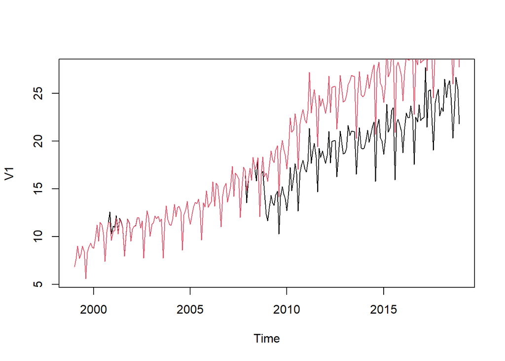

```r
trser.lin = lineal(trser, at$atip)
plot(ser)
lines((lambda*trser.lin + 1)^(1/lambda), col=2)
```

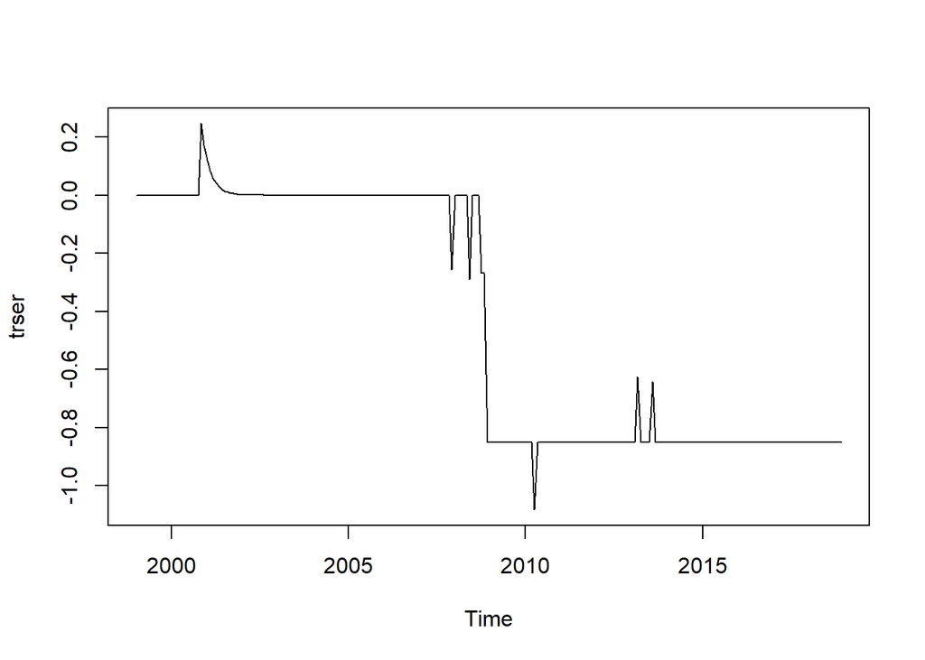

```r
plot(trser-trser.lin)
```

```r
trserEC.lin=trser.lin-
  coef(modEC)["vEa"]*vEa-
  coef(modEC)["vTD"]*vTD
```

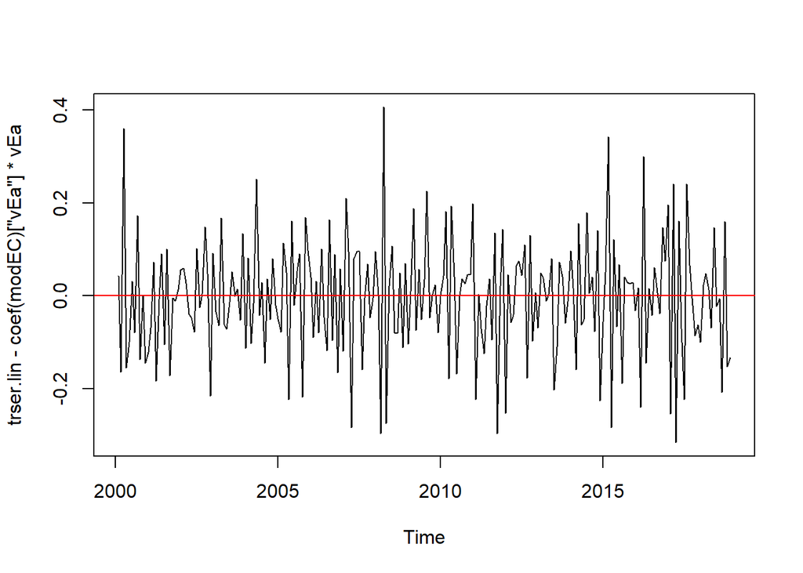

```r
d1d12trserEC.lin = diff(diff(trserEC.lin, 12))
plot(d1d12trserEC.lin)
abline(h = 0, col = "red")
```

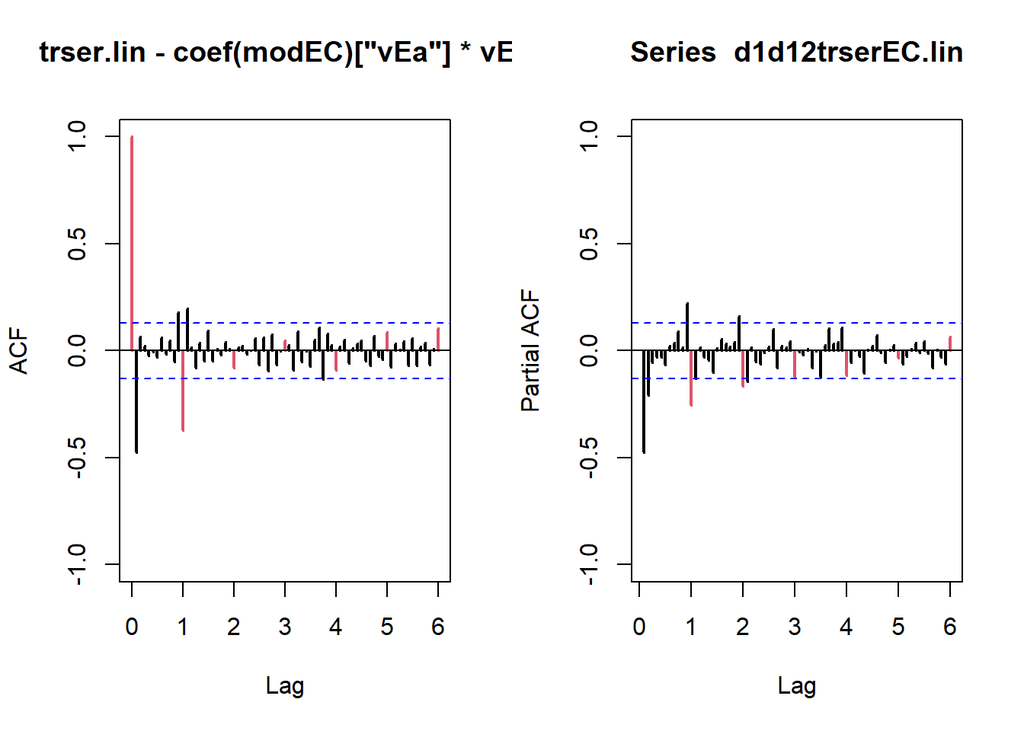

```r
par(mfrow=c(1,2))
acf(d1d12trserEC.lin,ylim=c(-1,1),lag.max=72,col=c(2,rep(1,11)),lwd=2)
pacf(d1d12trserEC.lin,ylim=c(-1,1),lag.max=72,col=c(rep(1,11),2),lwd=2)
```

```r
par(mfrow=c(1,1))
```

```r
(m1EClin=arima(trser.lin,order=c(2,1,0), seasonal=list(order=c(0,1,1),period=12), xreg=data.frame(vEa,vTD)))
```

```
##
## Call:
## arima(x = trser.lin, order = c(2, 1, 0), seasonal = list(order = c(0, 1, 1),
##     period = 12), xreg = data.frame(vEa, vTD))
##
## Coefficients:
##           ar1      ar2     sma1      vEa     vTD
##       -0.5787  -0.2282  -0.6959  -0.2175  0.0293
## s.e.   0.0657   0.0675   0.0603   0.0233  0.0017
##
## sigma^2 estimated as 0.008282:  log likelihood = 217.83,  aic = -423.65
```

```r
(m2EClin=arima(trser.lin,order=c(0,1,1), seasonal=list(order=c(0,1,1),period=12), xreg=data.frame(vEa,vTD)))
```

```
##
## Call:
## arima(x = trser.lin, order = c(0, 1, 1), seasonal = list(order = c(0, 1, 1),
##     period = 12), xreg = data.frame(vEa, vTD))
##
## Coefficients:
##           ma1     sma1      vEa     vTD
##       -0.5333  -0.6879  -0.2207  0.0290
## s.e.   0.0502   0.0596   0.0225  0.0015
##
## sigma^2 estimated as 0.008362:  log likelihood = 216.88,  aic = -423.75
```

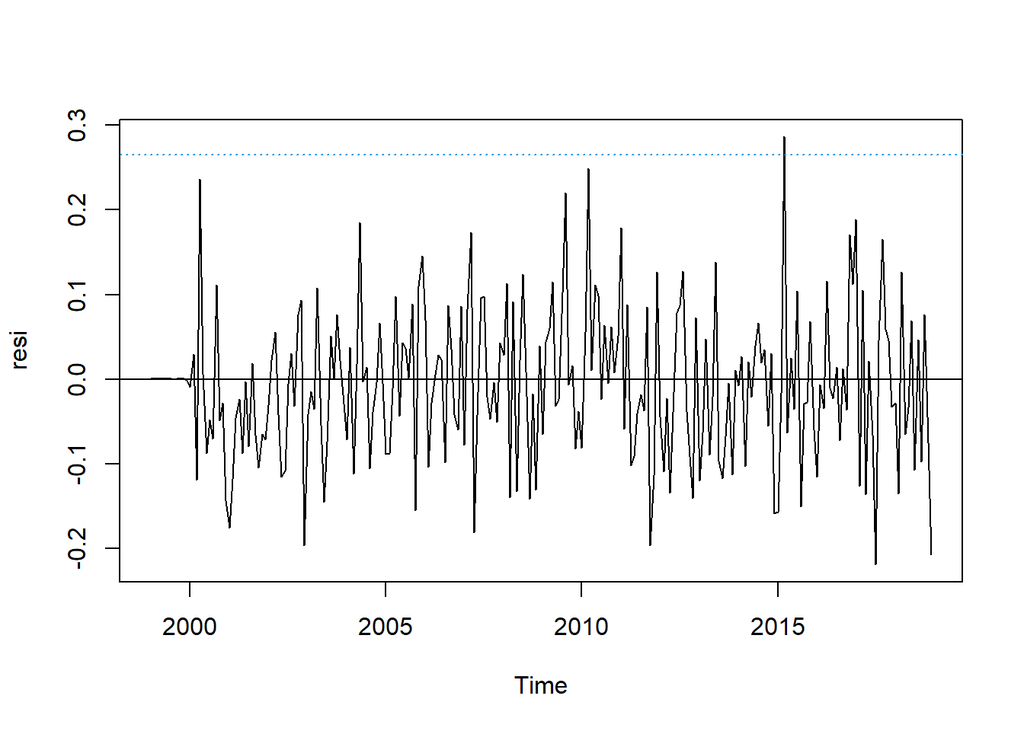

```r
resi=resid(m1EClin)

plot(resi)
abline(h=0)
abline(h=c(-3*sd(resi),3*sd(resi)),lty=3,col=4)
```

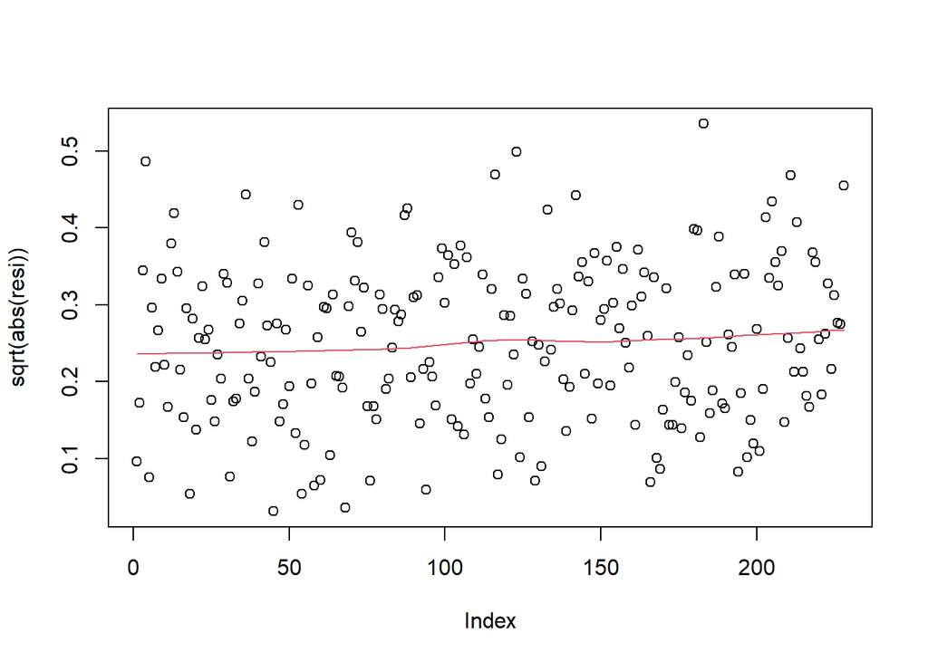

```r
resi = resi[13:length(resi)]
scatter.smooth(sqrt(abs(resi)), lpars=list(col=2))
```

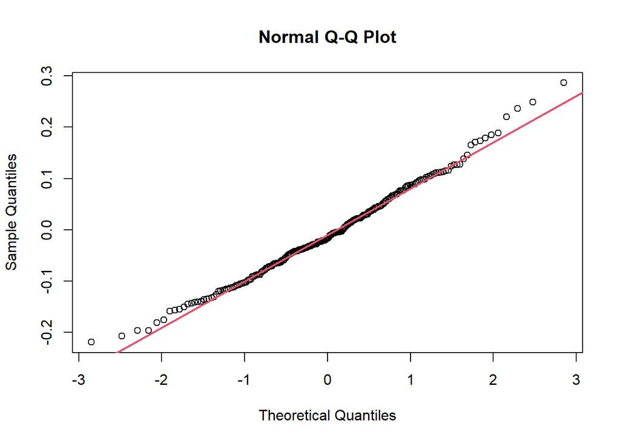

```r
qqnorm(resi)
qqline(resi,col=2,lwd=2)
```

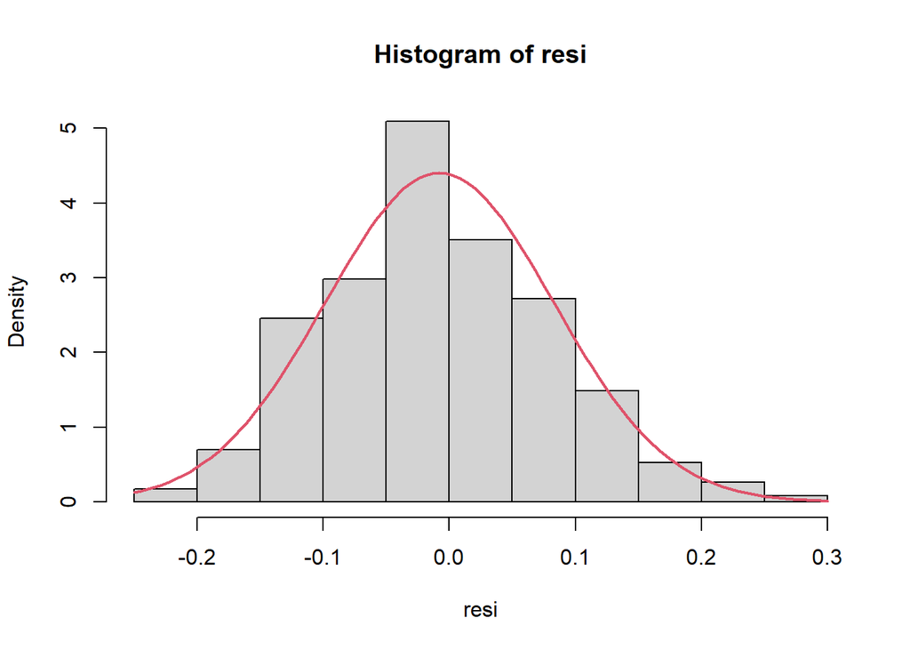

```r
hist(resi,breaks=15, freq=FALSE)
curve(dnorm(x, mean=mean(resi), sd=sd(resi)), col=2, lwd=2, add=T)
```

```r
shapiro.test(resi)
```

```
##
##  Shapiro-Wilk normality test
##
## data:  resi
## W = 0.99144, p-value = 0.2026
```

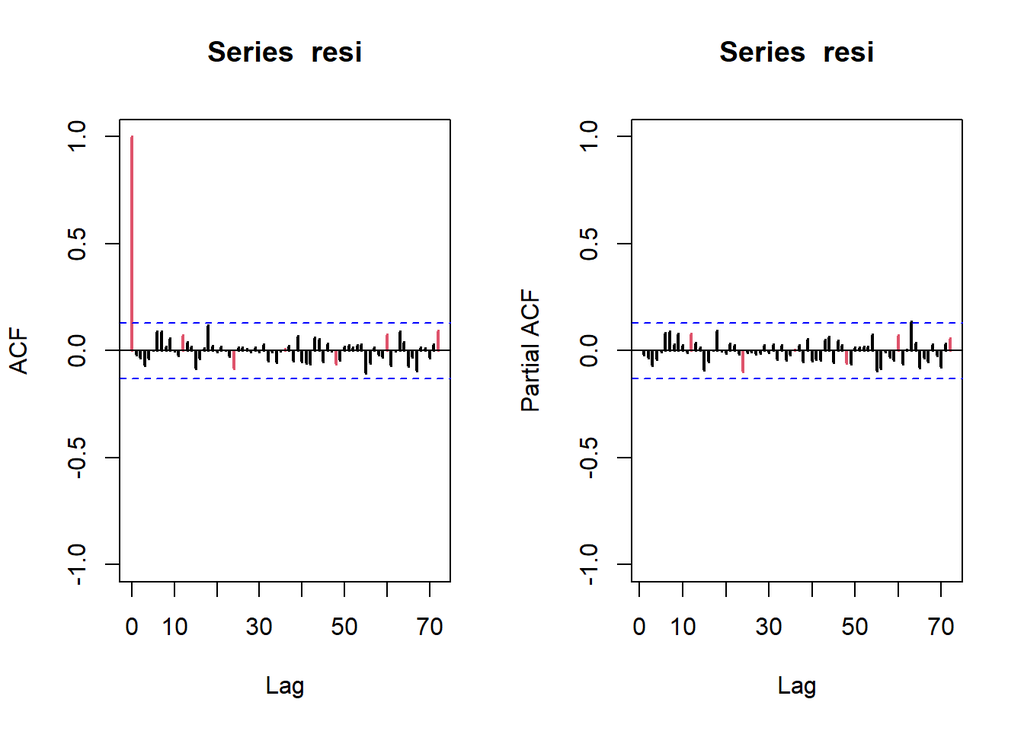

```r
par(mfrow=c(1,2))
acf(resi,ylim=c(-1,1),lag.max=72,col=c(2,rep(1,11)),lwd=2)
pacf(resi,ylim=c(-1,1),lag.max=72,col=c(rep(1,11),2),lwd=2)
```

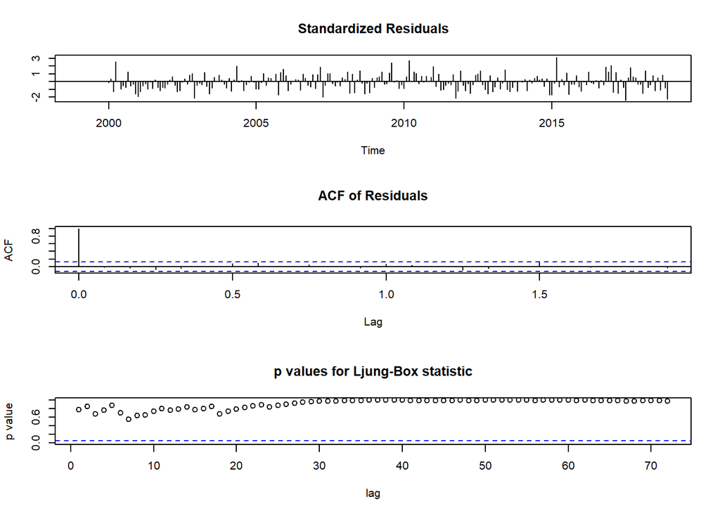

```r
par(mfrow=c(1,1))

tsdiag(m1EClin,gof.lag=72)
```

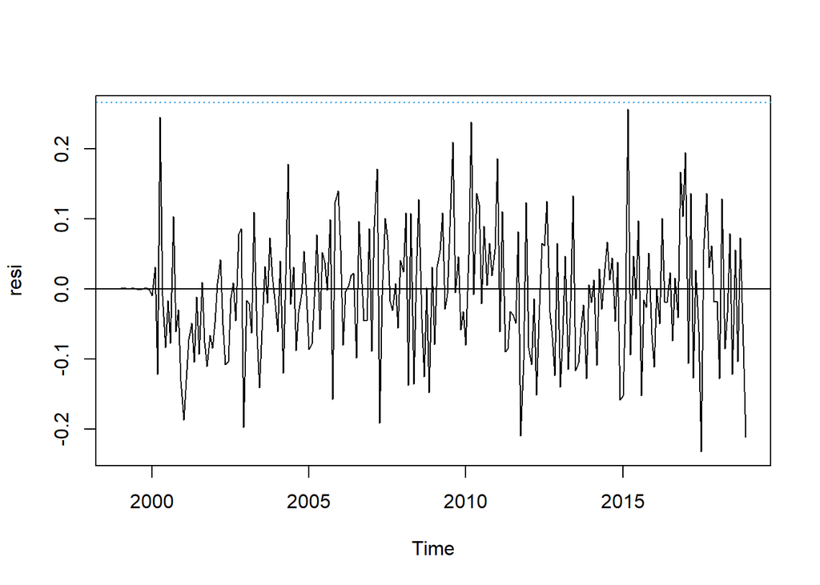

```r
resi=resid(m2EClin)

plot(resi)
abline(h=0)
abline(h=c(-3*sd(resi),3*sd(resi)),lty=3,col=4)
```

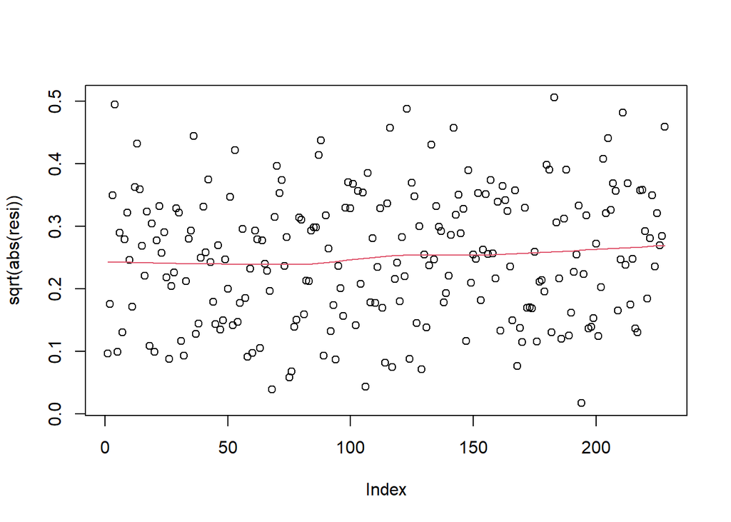

```r
resi = resi[13:length(resi)]
scatter.smooth(sqrt(abs(resi)), lpars=list(col=2))
```

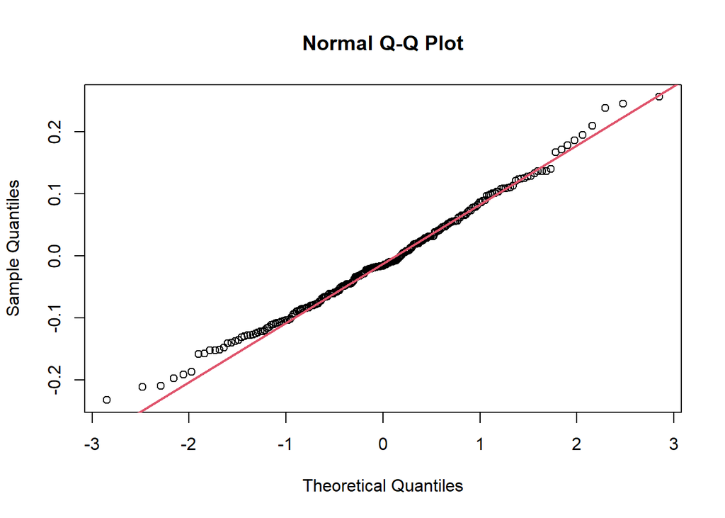

```r
qqnorm(resi)
qqline(resi,col=2,lwd=2)
```

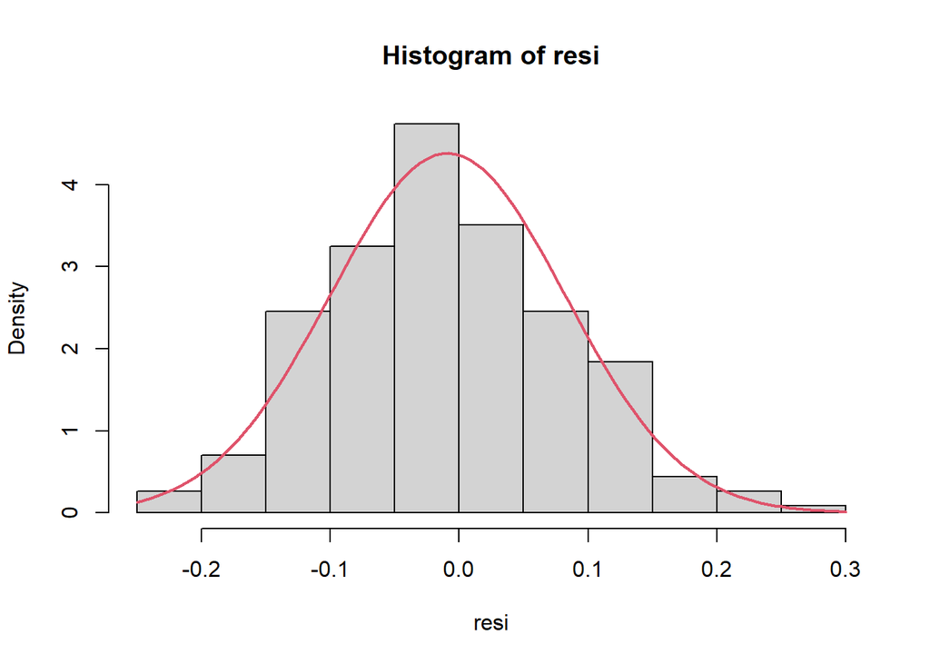

```r
hist(resi,breaks=15, freq=FALSE)
curve(dnorm(x, mean=mean(resi), sd=sd(resi)), col=2, lwd=2, add=T)
```

```r
shapiro.test(resi)
```

```
##
##  Shapiro-Wilk normality test
##
## data:  resi
## W = 0.99298, p-value = 0.3546
```

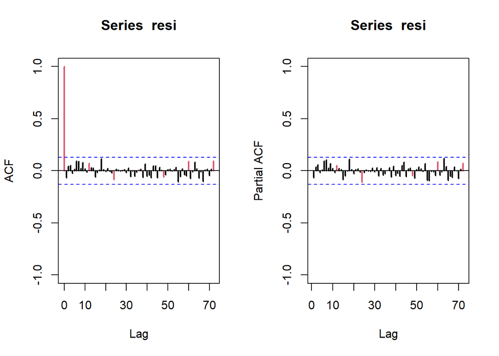

```r
par(mfrow=c(1,2))
acf(resi,ylim=c(-1,1),lag.max=72,col=c(2,rep(1,11)),lwd=2)
pacf(resi,ylim=c(-1,1),lag.max=72,col=c(rep(1,11),2),lwd=2)
```

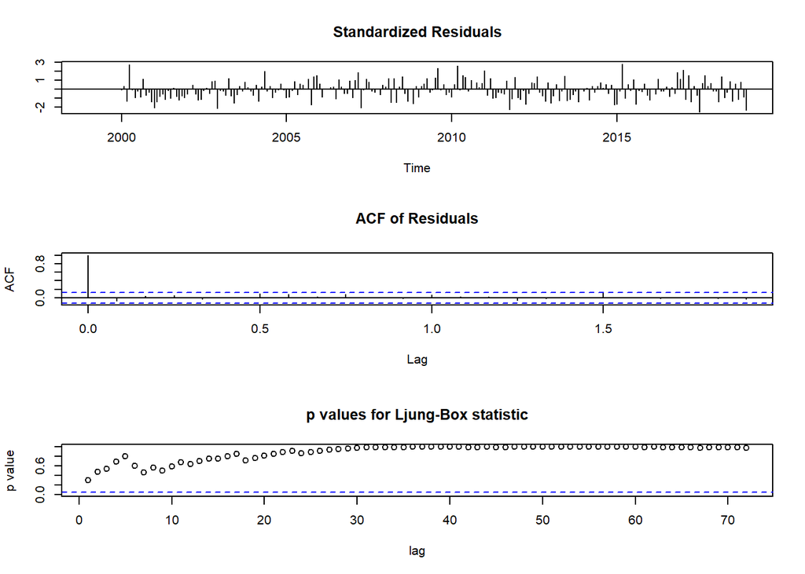

```r
par(mfrow=c(1,1))

tsdiag(m2EClin,gof.lag=72)
```

```r
(AIC=AIC(m1EClin)+2*nrow(at$atip))
```

```
## [1] -407.6513
```

```r
(AIC=AIC(m2EClin)+2*nrow(at$atip))
```

```
## [1] -407.7512
```

```r
(BIC=BIC(m1EClin)+log(length(ser)**nrow(at$atip)))
```

```
## [1] -359.2565
```

```r
(BIC=BIC(m2EClin)+log(length(ser)**nrow(at$atip)))
```

```
## [1] -362.7814
```

```r
min(Mod(polyroot(c(1,-m1EClin$model$phi))))
```

```
## [1] 2.093236
```

```r
min(Mod(polyroot(c(1,m1EClin$model$theta))))
```

```
## [1] 1.030671
```

```r
min(Mod(polyroot(c(1,m2EClin$model$theta))))
```

```
## [1] 1.031663
```

```r
ultim=c(2017,12)
trser.lin_12 = window(trser.lin, end = ultim)
vEa2=window(vEa,end=ultim)
vTD2=window(vTD,end=ultim)
```

```r
(m1EClin_12=arima(trser.lin_12,order=c(2,1,0),seasonal=list(order=c(0,1,1),period=12),xreg=data.frame(vEa2,vTD2)))
```

```
##
## Call:
## arima(x = trser.lin_12, order = c(2, 1, 0), seasonal = list(order = c(0, 1,
##     1), period = 12), xreg = data.frame(vEa2, vTD2))
##
## Coefficients:
##           ar1      ar2     sma1     vEa2    vTD2
##       -0.5542  -0.2254  -0.7144  -0.2282  0.0289
## s.e.   0.0667   0.0680   0.0606   0.0240  0.0017
##
## sigma^2 estimated as 0.008134:  log likelihood = 207.74,  aic = -403.48
```

```r
(m2EClin_12=arima(trser.lin_12,order=c(0,1,1),seasonal=list(order=c(0,1,1),period=12),xreg=data.frame(vEa2,vTD2)))
```

```
##
## Call:
## arima(x = trser.lin_12, order = c(0, 1, 1), seasonal = list(order = c(0, 1,
##     1), period = 12), xreg = data.frame(vEa2, vTD2))
##
## Coefficients:
##           ma1     sma1     vEa2    vTD2
##       -0.5239  -0.7068  -0.2316  0.0286
## s.e.   0.0520   0.0598   0.0232  0.0016
##
## sigma^2 estimated as 0.008173:  log likelihood = 207.36,  aic = -404.72
```

```r
vEa2=window(vEa,start=ultim+c(0,1))
vTD2=window(vTD,start=ultim+c(0,1))

pre1=predict(m1EClin_12,n.ahead = 12,newxreg=data.frame(vEa2,vTD2))
pre2=predict(m2EClin_12,n.ahead = 12,newxreg=data.frame(vEa2,vTD2))

wLS=sum(at$atip[at$atip[,2]=="LS",3])
```

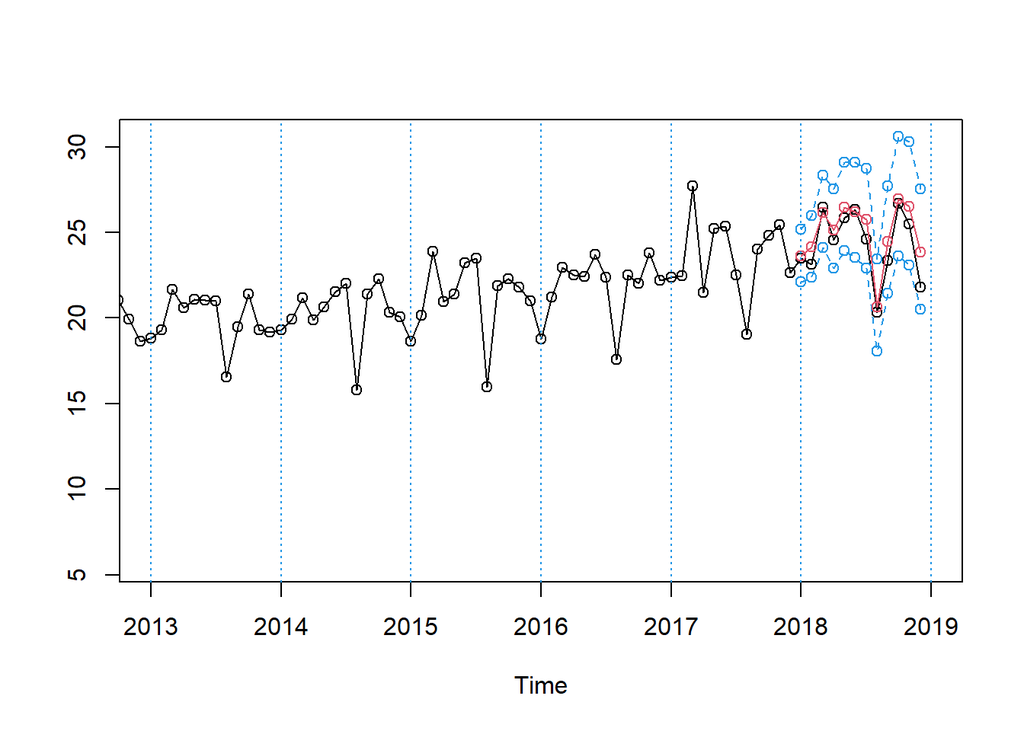

```r
tl1 = (lambda*(pre1$pred+wLS - 1.96*pre1$se) + 1)^(1/lambda)  # límit inferior
tu1 = (lambda*(pre1$pred+wLS + 1.96*pre1$se) + 1)^(1/lambda)  # límit superior
pr1 = (lambda*(pre1$pred+wLS) + 1)^(1/lambda)             # prediccions puntuals


ts.plot(ser,tl,tu,pr,lty=c(1,2,2,1),col=c(1,4,4,2),xlim=c(2013,2019),type="o");
abline(v=2013:2019,lty=3,col=4)
```

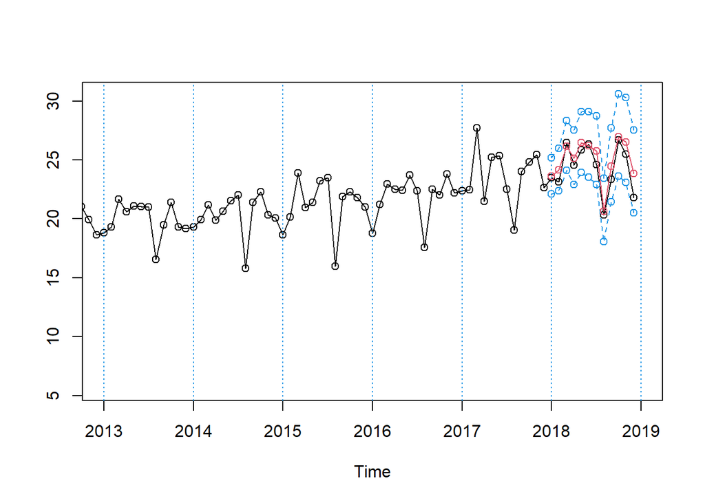

```r
tl2 = (lambda*(pre2$pred+wLS - 1.96*pre2$se) + 1)^(1/lambda)  # límit inferior
tu2 = (lambda*(pre2$pred+wLS + 1.96*pre2$se) + 1)^(1/lambda)  # límit superior
pr2 = (lambda*(pre2$pred+wLS) + 1)^(1/lambda)             # prediccions puntuals


ts.plot(ser,tl,tu,pr,lty=c(1,2,2,1),col=c(1,4,4,2),xlim=c(2013,2019),type="o");
abline(v=2013:2019,lty=3,col=4)
```

```r
(RMSE1=sqrt(mean((obs-pr1)^2)))
```

```
## [1] 0.9613394
```

```r
(MAE1=mean(abs(obs-pr1)))
```

```
## [1] 0.7715523
```

```r
(RMSPE1=sqrt(mean(((obs-pr1)/obs)^2)))
```

```
## [1] 0.04154407
```

```r
(MAPE1=mean(abs(obs-pr1)/obs))
```

```
## [1] 0.03249944
```

```r
(RMSE2=sqrt(mean((obs-pr2)^2)))
```

```
## [1] 0.9232439
```

```r
(MAE2=mean(abs(obs-pr2)))
```

```
## [1] 0.7310439
```

```r
(RMSPE2=sqrt(mean(((obs-pr2)/obs)^2)))
```

```
## [1] 0.03995234
```

```r
(MAPE2=mean(abs(obs-pr2)/obs))
```

```
## [1] 0.03077244
```

```r
(CI1 = mean(tu1-tl1))
```

```
## [1] 3.928588
```

```r
(CI2 = mean(tu2-tl2))
```

```
## [1] 3.662591
```

```r
result_table <- data.frame(Model = c("Model 1", "Model 2"),
                          RMSE = c(RMSE1, RMSE2),
                          MAE = c(MAE1, MAE2),
                          RMSPE = c(RMSPE1, RMSPE2),
                          MAPE = c(MAPE1, MAPE2),
                          CI = c(CI1, CI2))

print(result_table)
```

```
##     Model      RMSE       MAE      RMSPE       MAPE       CI
## 1 Model 1 0.9613394 0.7715523 0.04154407 0.03249944 3.928588
## 2 Model 2 0.9232439 0.7310439 0.03995234 0.03077244 3.662591
```

Ens quedarem amb el segon model per fer prediccions

## Prediccions

```r
(m2EClin=arima(trser.lin,order=c(0,1,1),seasonal=list(order=c(0,1,1),period=12),xreg=data.frame(vEa,vTD)))
```

```
##
## Call:
## arima(x = trser.lin, order = c(0, 1, 1), seasonal = list(order = c(0, 1, 1),
##     period = 12), xreg = data.frame(vEa, vTD))
##
## Coefficients:
##           ma1     sma1      vEa     vTD
##       -0.5333  -0.6879  -0.2207  0.0290
## s.e.   0.0502   0.0596   0.0225  0.0015
##
## sigma^2 estimated as 0.008362:  log likelihood = 216.88,  aic = -423.75
```

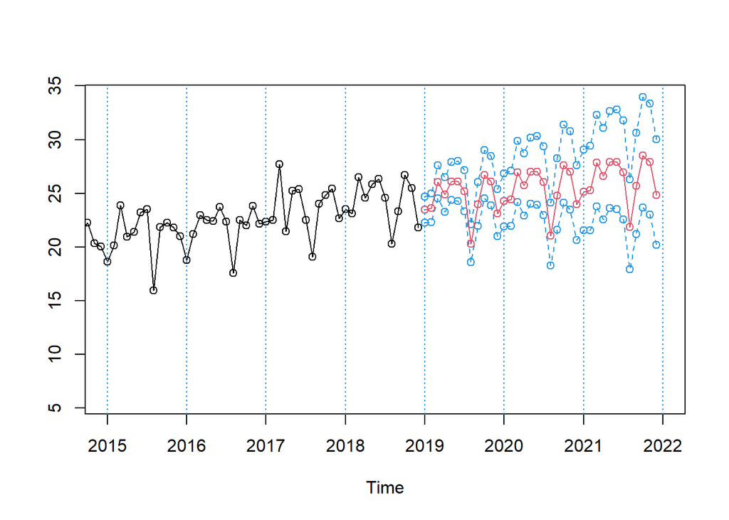

```r
pre=predict(m2EClin, n.ahead = 36,newxreg=data.frame(vEa2,vTD2))

tl = (lambda*(pre$pred+wLS - 1.96*pre$se) + 1)^(1/lambda)  # límit inferior
tu = (lambda*(pre$pred+wLS + 1.96*pre$se) + 1)^(1/lambda)  # límit superior
pr = (lambda*(pre$pred+wLS) + 1)^(1/lambda)             # prediccions puntuals


ts.plot(ser,tl,tu,pr,lty=c(1,2,2,1),col=c(1,4,4,2),xlim=c(2015,2022),type="o");
abline(v=2013:2022,lty=3,col=4)
```